# Minería de Datos (Master en Data Science, UIMP-UC)

## Técnicas de aprendizaje supervisado

### Practica de Intercomparación aplicada a datos meteorológicos

#### Santander Meteorology Group

En esta práctica haremos una intercomparación de varias de las técnicas de aprendizaje supervisado vistas a lo largo de la asignatura (CART, k-NN, GLMs y Random Forests). Por tanto, pretende ser un repaso general de cara al examen en el que el objetivo es tratar de entender las ventajas y limitaciones de las distintas técnicas para un caso de aplicación particular; la predicción de precipitación. La entrega consistirá en un notebook (Jupyter o R-Markdown), junto con el archivo html que éste genera. Ambos ficheros se entregarán a través del Moodle de la asignatura en la tarea correspondiente.

## Conjunto de datos meteo

Comenzaremos cargando el dataset meteo, que ya ha sido utilizado en sesiones anteriores. Como ya sabéis, la variable objetivo en este dataset es la precipitation diaria en Lisboa durante el período 1979-2008, y para modelizar ésta se dispone de un conjunto de 8 variables meteorológicas predictoras que describen la circulación de larga escala definidas sobre un dominio geográfico que incluye 40 puntos sobre la Península Ibérica. (en total 8×40=320 variables explicativas). Las variables predictoras son:

- altura geopotencial en 500 hPa (Z500)
- temperatura del aire en 850 hPa, 700 hPa, 500 hPa (ta850, ta700 y ta500), y en superficie (tas)
- humedad específica del aire en 850 hPa y 500 hPa (hus850, hus500)
- presión a nivel del mar (psl)

Para agilizar los tiempos de cómputo, reduciremos la dimensionalidad del problema. Como ya se ha visto en sesiones anteriores, una alternativa para tal fin es el uso de PCs. Sin embargo, para no limitar la interpretabilidad de los resultados obtenidos con árboles, utilizaremos otra aproximación aquí. En concreto, optaremos por un análisis de correlaciones, en el que se calcula la correlación de Spearman entre nuestra variable objetivo y todas las variables predictoras disponibles. La asunción de partida es que cuanto más fuerte sea esta correlación, mayor es el vínculo físico entre predictando y predictor, y por tanto, más útil es la información que nos aporta ese predictor. Por tanto, este análisis nos permite descartar predictores poco relevantes. Siguiendo esta idea, calcularemos la correlación existente entre nuestro predictando y los 320 predictores, y eliminaremos aquellos con correlaciones entre -0.4 y 0.4. ¿Cuánto se ha reducido la dimensionalidad del problema?

Primero se instalan y cargan paquetes a utilizar, se cargan los datos y se acondiciona el dataset.

```r
#install.packages("lattice")
#install.packages("caret")
#install.packages("ggplot2")
#install.packages("randomForest")
library(caret)
library(class)
library(ggplot2)
library(pROC)
library(tree)
library(rpart)
library(rpart.plot)
library(randomForest)
library(FNN)
```

```r
#Cargando datos
dataset = read.csv("meteo.csv")

#Explorando datos
str(dataset)
head(dataset)
```

```
'data.frame':	10958 obs. of  322 variables:
 $ X   : int  1 2 3 4 5 6 7 8 9 10 ...
 $ y   : num  10.9 0.6 13 0 0 1.2 1.1 0 0 0.7 ...
 $ X1  : num  57043 56963 56523 54628 53584 ...
 $ X2  : num  56535 56493 55971 53980 53391 ...
 $ X3  : num  55884 55931 55304 53494 53310 ...
 $ X4  : num  55176 55340 54498 53073 53293 ...
 $ X5  : num  54458 54769 53725 52616 53340 ...
 $ X6  : num  56980 56857 56515 54776 53782 ...
 $ X7  : num  56461 56362 55978 54089 53498 ...
 $ X8  : num  55800 55777 55327 53517 53307 ...
 $ X9  : num  55051 55164 54570 53013 53213 ...
 $ X10 : num  54319 54585 53863 52501 53157 ...
 $ X11 : num  56900 56724 56467 54908 54015 ...
 $ X12 : num  56368 56187 55965 54205 53674 ...
```

[output cut: 86 more lines]

A data.frame: 6 × 322

|  | X <int> | y <dbl> | X1 <dbl> | X2 <dbl> | X3 <dbl> | X4 <dbl> | X5 <dbl> | X6 <dbl> | X7 <dbl> | X8 <dbl> | ⋯ | X311 <dbl> | X312 <dbl> | X313 <dbl> | X314 <dbl> | X315 <dbl> | X316 <dbl> | X317 <dbl> | X318 <dbl> | X319 <dbl> | X320 <dbl> |
| --- | --- | --- | --- | --- | --- | --- | --- | --- | --- | --- | --- | --- | --- | --- | --- | --- | --- | --- | --- | --- | --- |
| 1 | 1 | 10.9 | 57042.96 | 56534.84 | 55884.40 | 55175.59 | 54458.21 | 56980.27 | 56460.59 | 55800.02 | ⋯ | 101985.9 | 101627.3 | 101357.2 | 101110.7 | 101291.0 | 101814.9 | 101479.4 | 101164.5 | 100970.7 | 100905.3 |
| 2 | 2 | 0.6 | 56963.20 | 56493.45 | 55930.82 | 55340.20 | 54768.63 | 56856.57 | 56361.95 | 55776.76 | ⋯ | 102048.1 | 102069.7 | 102204.5 | 102480.3 | 102858.8 | 101973.3 | 102033.3 | 102165.5 | 102323.9 | 102534.2 |
| 3 | 3 | 13.0 | 56522.59 | 55971.40 | 55304.34 | 54498.03 | 53725.15 | 56514.84 | 55977.71 | 55327.28 | ⋯ | 102399.1 | 102448.4 | 102438.3 | 102434.3 | 102339.8 | 102669.7 | 102565.5 | 102530.3 | 102453.6 | 102487.1 |
| 4 | 4 | 0.0 | 54627.98 | 53979.80 | 53494.05 | 53072.98 | 52616.36 | 54776.17 | 54089.05 | 53516.98 | ⋯ | 100970.0 | 100672.8 | 100360.7 | 100133.7 | 100028.4 | 101126.2 | 100700.0 | 100381.3 | 100118.3 | 100319.8 |
| 5 | 5 | 0.0 | 53584.38 | 53391.01 | 53310.38 | 53292.82 | 53340.13 | 53781.70 | 53498.13 | 53306.82 | ⋯ | 100652.7 | 100663.5 | 100747.7 | 100934.0 | 101015.8 | 100801.6 | 100685.3 | 100777.5 | 100909.4 | 101164.7 |
| 6 | 6 | 1.2 | 54221.86 | 54220.24 | 54328.55 | 54772.49 | 55251.11 | 54391.11 | 54345.93 | 54284.05 | ⋯ | 101358.6 | 101511.5 | 101798.9 | 102142.2 | 102368.5 | 101438.7 | 101440.9 | 101685.3 | 102030.7 | 102311.9 |

Es importante observar que el dataset contiene una primera columna que es un contador y no hace parte de los predictores ni predictando, por lo cual se eliminará. Adicionalmente, se observan 10958 observaciones que corresponden a la toma de los datos de precipitación y las variables por día de los 30 años del periodo de estudio (1979-2008).

```r
#Eliminando primero columna debido a que es un consecutivo
df = dataset[, -1]
head(df)
```

A data.frame: 6 × 321

|  | y <dbl> | X1 <dbl> | X2 <dbl> | X3 <dbl> | X4 <dbl> | X5 <dbl> | X6 <dbl> | X7 <dbl> | X8 <dbl> | X9 <dbl> | ⋯ | X311 <dbl> | X312 <dbl> | X313 <dbl> | X314 <dbl> | X315 <dbl> | X316 <dbl> | X317 <dbl> | X318 <dbl> | X319 <dbl> | X320 <dbl> |
| --- | --- | --- | --- | --- | --- | --- | --- | --- | --- | --- | --- | --- | --- | --- | --- | --- | --- | --- | --- | --- | --- |
| 1 | 10.9 | 57042.96 | 56534.84 | 55884.40 | 55175.59 | 54458.21 | 56980.27 | 56460.59 | 55800.02 | 55051.15 | ⋯ | 101985.9 | 101627.3 | 101357.2 | 101110.7 | 101291.0 | 101814.9 | 101479.4 | 101164.5 | 100970.7 | 100905.3 |
| 2 | 0.6 | 56963.20 | 56493.45 | 55930.82 | 55340.20 | 54768.63 | 56856.57 | 56361.95 | 55776.76 | 55164.26 | ⋯ | 102048.1 | 102069.7 | 102204.5 | 102480.3 | 102858.8 | 101973.3 | 102033.3 | 102165.5 | 102323.9 | 102534.2 |
| 3 | 13.0 | 56522.59 | 55971.40 | 55304.34 | 54498.03 | 53725.15 | 56514.84 | 55977.71 | 55327.28 | 54569.78 | ⋯ | 102399.1 | 102448.4 | 102438.3 | 102434.3 | 102339.8 | 102669.7 | 102565.5 | 102530.3 | 102453.6 | 102487.1 |
| 4 | 0.0 | 54627.98 | 53979.80 | 53494.05 | 53072.98 | 52616.36 | 54776.17 | 54089.05 | 53516.98 | 53012.86 | ⋯ | 100970.0 | 100672.8 | 100360.7 | 100133.7 | 100028.4 | 101126.2 | 100700.0 | 100381.3 | 100118.3 | 100319.8 |
| 5 | 0.0 | 53584.38 | 53391.01 | 53310.38 | 53292.82 | 53340.13 | 53781.70 | 53498.13 | 53306.82 | 53213.26 | ⋯ | 100652.7 | 100663.5 | 100747.7 | 100934.0 | 101015.8 | 100801.6 | 100685.3 | 100777.5 | 100909.4 | 101164.7 |
| 6 | 1.2 | 54221.86 | 54220.24 | 54328.55 | 54772.49 | 55251.11 | 54391.11 | 54345.93 | 54284.05 | 54525.99 | ⋯ | 101358.6 | 101511.5 | 101798.9 | 102142.2 | 102368.5 | 101438.7 | 101440.9 | 101685.3 | 102030.7 | 102311.9 |

Recordemos que para agilizar los tiempos de cómputo se reducirá la dimensionalidad del problema, pero para no limitar la interpretabilidad de los resultados obtenidos con árboles, utilizaremos un análisis de correlaciones entre nuestra variable objetivo y todas las variables predictoras disponibles (correlación de Spearman). Cuanto más fuerte sea esta correlación, mayor es el vínculo físico entre predictando y predictor, y por tanto, más útil es la información que nos aporta ese predictor. De los 320 predictores se eliminarán aquellos con correlaciones entre -0.4 y 0.4.

```r
x= df[,-1]
y= df[,1]
r.xy = rep(NA, 320)
for (i in 1:ncol(x)) {
  r.xy[i] = cor(y, x[, i], method = "spearman")
}
ind.sele = which(abs(r.xy) > 0.4)
length(ind.sele)
```

37

Como se observa en los resultados, y respondiendo a la pregunta, se redujo de 320 predictores a 37 que presentan una correlación fuerte con la variable objetivo. Esta reducción ayudará a evitar el sobreajuste y mejorar la interpretabilidad del modelo. Con los resultados de más adelante podremos comprobar si esta reducción es significativa frente a la explicabilidad de la variable objetivo.

Para simplificar aún más los cálculos, nos limitaremos a los primeros 5000 días del dataset. Además, se considerará una partición de la muestra en dos subconjuntos independientes, train y test, escogidos aleatoriamente (75% para entrenar y 25% para validar).

```r
n = 5000
df.y = y[1:n]
df.x = x[1:n, ind.sele]

#partición de train y test 75% y 25%
set.seed(2103)
ind.train = sample(1:n, round(0.75*n))
indtest = setdiff(1:n, ind.train)
```

2670

891

0.712

0.7128

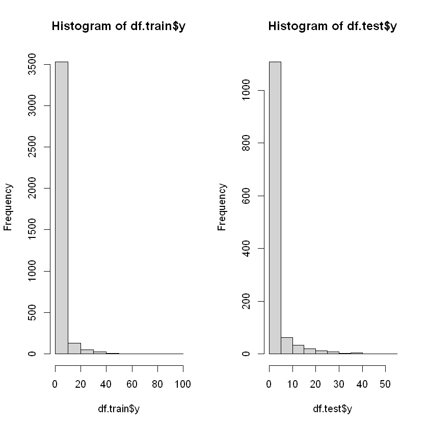

```r
#explorando datos
df.train = data.frame(y = df.y[ind.train], x = df.x[ind.train, ])
df.test = data.frame(y = df.y[indtest], x = df.x[indtest, ])

par(bg = "white", mfrow = c(1, 2))
hist(df.train$y, breaks = 10)
hist(df.test$y, breaks = 10)

#cantidad de ceros
sum(df.train$y == 0)
sum(df.test$y == 0)

#porcentaje de ceros
sum(df.train$y == 0)/length(df.train$y)
sum(df.test$y == 0)/length(df.test$y)
```

En el histograma se puede observar cómo están compuestos cada uno de los conjuntos de datos de train y test, donde se evidencia que existe una gran cantidad de días con valores entre 0 y 10, y si hacemos la suma del número de ceros en los conjuntos de datos vemos que alrededor del 70% de los datos son 0. Este es un aspecto importante a considerar para los análisis y el entrenamiento de cada uno de los modelos.

Adicionalmente, se observa que hay precipitaciones en train de hasta aproximadamente 100 mm y en test solo hasta aproximadamente 50 mm. En ambos casos, estos valores son pocos por lo cual se podrían considerar valores atípicos o eventos extremos de precipitación. En general se observa que en train hay más precipitaciones altas que test, siento estos eventos extremos poco frecuentes, pero importante a considerar que existen para los análisis a realizar.

```r
summary(df.train$y)
summary(df.test$y)
```

```
   Min. 1st Qu.  Median    Mean 3rd Qu.    Max.
  0.000   0.000   0.000   1.869   0.300  95.500
```

```
   Min. 1st Qu.  Median    Mean 3rd Qu.    Max.
  0.000   0.000   0.000   1.774   0.300  54.000
```

## Árboles de clasificación y regresión (2.5 puntos)

Como ya hemos visto en sesiones anteriores, tendremos que crear dos modelos independientes, uno para la clasificación del evento binario lluvia/no lluvia y otro para el evento continuo cantidad de lluvia. Nos centramos en primer lugar en la clasificación lluvia/no lluvia. Para ello, tenemos que crear la variable binaria ocurrencia de precipitación (considera un umbral de 1 mm) y construir el dataframe asociado al problema.

A continuación construiremos el árbol completo (usa la función tree). ¿Cuántos nodos terminales obtienes? ¿Qué variables predictoras dan lugar a las primeras subdivisiones del árbol?

Primero empezamos con el modelo de clasificación del evento binario lluvia/no lluvia. Se crea la variable binaria de ocurrencia de precipitación considerando el umbral de 1mm y se construye el dataframe.

```r
#creación de variable binaria
df.y.occ.1 = as.factor(ifelse(df.y >= 1, 1, 0))

#dataframe
df.occ.1 = data.frame(y = df.y.occ.1, predictors = df.x)
str(df.occ.1)
```

```
'data.frame':	5000 obs. of  38 variables:
 $ y              : Factor w/ 2 levels "0","1": 2 1 2 1 1 2 2 1 1 1 ...
 $ predictors.X1  : num  57043 56963 56523 54628 53584 ...
 $ predictors.X2  : num  56535 56493 55971 53980 53391 ...
 $ predictors.X3  : num  55884 55931 55304 53494 53310 ...
 $ predictors.X4  : num  55176 55340 54498 53073 53293 ...
 $ predictors.X5  : num  54458 54769 53725 52616 53340 ...
 $ predictors.X6  : num  56980 56857 56515 54776 53782 ...
 $ predictors.X7  : num  56461 56362 55978 54089 53498 ...
 $ predictors.X8  : num  55800 55777 55327 53517 53307 ...
 $ predictors.X9  : num  55051 55164 54570 53013 53213 ...
 $ predictors.X10 : num  54319 54585 53863 52501 53157 ...
 $ predictors.X12 : num  56368 56187 55965 54205 53674 ...
 $ predictors.X13 : num  55721 55587 55360 53594 53378 ...
 $ predictors.X14 : num  54946 54947 54646 53021 53200 ...
```

[output cut: 24 more lines]

Para empezar el análisis, construiremos el árbol completo con la función tree de tal forma que obtengamos los nodos terminales que permitan llegar a un resultado con error cero y conocer las variables más importantes. Para esto, se establece en la función los hyper-parámetros que obliga a construirlo completo. Por un lado, esta mincut que representa el número mínimo de observaciones requeridas en un nodo después de dividirlo, es decir, que para el valor de 1 cada nodo hijo va a contener al menos 1 observación para permitir divisiones completas. Luego esta minsize que representa el tamaño mínimo permitido de un nodo terminal, es decir el mínimo necesario para dividirse, el cual debe ser 2 para que sea coherente con mincut. Finalmente, esta mindev, que controla la variación mínima de la desviación para que una división sea considerada significativa, la cual se coloca en cero para garantizar la mayor cantidad de divisiones.

```
Classification tree:
tree(formula = y ~ ., data = df.occ.1, subset = ind.train, mincut = 1,
    minsize = 2, mindev = 0)
Number of terminal nodes:  302
Residual mean deviance:  0 = 0 / 3448
Misclassification error rate: 0 = 0 / 3750
```

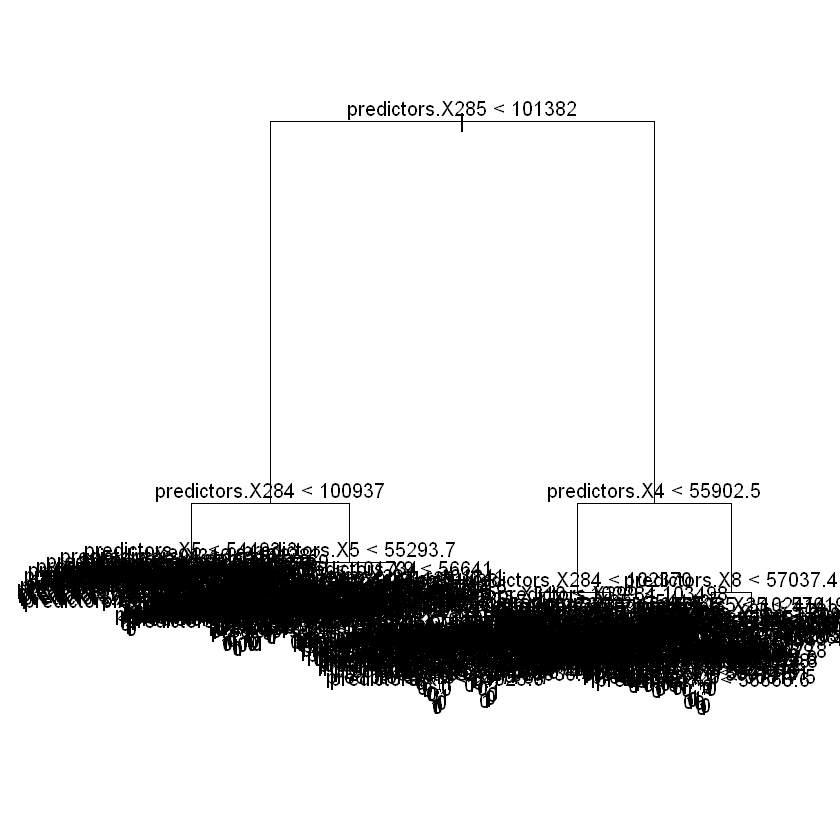

```r
tree.model.1 = tree(y ~ ., df.occ.1, subset = ind.train,
                  mincut = 1, minsize = 2, mindev = 0)

par(bg = "white")
plot(tree.model.1); text(tree.model.1, pretty = F)
summary(tree.model.1)
```

Respondiendo a la pregunta, en este primer ejercicio de árbol completo se observan 302 nodos terminales, destacando variables como X285, X284, X4, X5, y X8, de resto es difícil de interpretar el árbol debido a la cantidad de divisiones que se generan. Recordemos que los árboles completos no son adecuados para generalizar debido al sobreajuste. Es importante mencionar que, teniendo en cuenta la descripción el dataset las primeras dos variables están relacionada con la presión a nivel del mar, las otras tres con la altura geopotencial.

Para simplificar este árbol tan complejo tendremos que podarlo adecuadamente. Utiliza una cross-validación con un 10-fold para encontrar el número de nodos terminales del árbol óptimo. ¿Cuál es este número? ¿Qué predictores aparecen como los más importantes?

Primero se determina el número de nodos terminales óptimo para el árbol utilizando cross-validación con un 10-fold. Como se desconoce la profundidad del árbol, se hace un análisis de la deviance versus el número de hojas para determinar con cuantas hojas se reduce significativamente este indicador y saber por dónde podar.

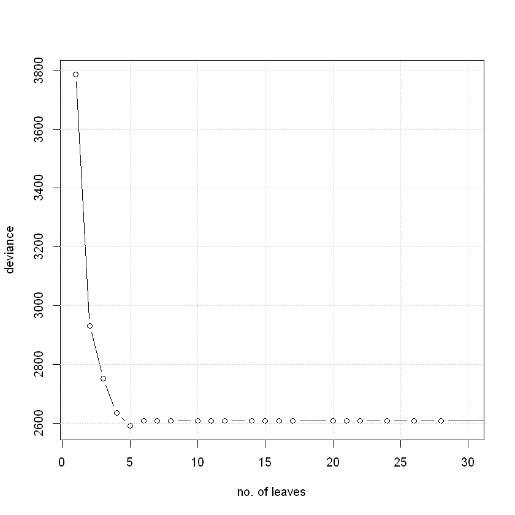

```r
set.seed(2103)
t.cv.1 = cv.tree(tree.model.1, K = 10)
par(bg = "white")
plot(t.cv.1$size, t.cv.1$dev, type = "b", xlim = c(1, 30),
     xlab = "no. of leaves", ylab = "deviance")
grid()
```

Se puede considerar como número adecuado de hojas 6, debido a que en la gráfica de deviance y número de hojas se observa que alrededor de este número el deviance se estabiliza y más hojas no mejoran el rendimiento del modelo. En este punto, se puede considerar que el modelo tiene un buen equilibrio entre ajuste y generalización, partiendo de que esta métrica mide la calidad de ajuste del árbol, donde muchas hojas reducen el deviance pero entre más se reduce se capturan patrones específicos de los datos y no se logra obtener un modelo que generalice, por lo cual se poda el árbol completo con esta cantidad:

```
Classification tree:
snip.tree(tree = tree.model.1, nodes = c(4L, 15L, 11L, 10L, 6L,
14L))
Variables actually used in tree construction:
[1] "predictors.X285" "predictors.X284" "predictors.X5"   "predictors.X4"
[5] "predictors.X8"
Number of terminal nodes:  6
Residual mean deviance:  0.6594 = 2469 / 3744
Misclassification error rate: 0.1424 = 534 / 3750
```

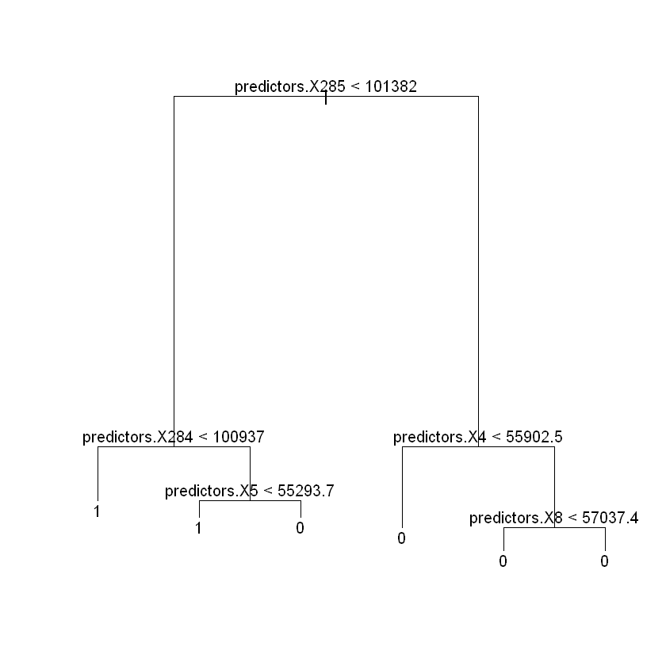

```r
tree.model.opt.1 = prune.tree(tree.model.1, best = 6)
par(bg = "white")
plot(tree.model.opt.1); text(tree.model.opt.1, pretty = F)
summary(tree.model.opt.1)
```

Con el árbol podado vemos que nos quedamos con los predictores X285 (principal), X284, X4, X5 y X8, donde los primeros dos están relacionados con la presión a nivel del mar, y los otros dos con la altura geopotencial, como se había mencionado anteriormente.

Es importante mencionar que en esta oportunidad se usó el criterio de número de hojas para determinar la poda del árbol, pero se pudo explorar la profundidad de este para luego podarlo (con el paquete caret). Ambos métodos dan un resultado similar a la hora de comparar los resultados de acuerdo con lo que se hizo en prácticas previas.

Se utiliza este árbol óptimo para predecir en el test, se calcula el accuracy y se guardan las predicciones.

```r
#predcción
pred.tree.1 = predict(tree.model.opt.1, df.occ.1[indtest, ], type = "class")
```

```r
#accuracy
acc.class = function(x, y) {
  stopifnot(length(x) == length(y))
  return(sum(diag(table(x, y))) / length(x))
}

acc.tree.1 = acc.class(pred.tree.1, df.occ.1$y[indtest])

cat("Accuracy modelo tree para ocurrencia de lluvia: ", acc.tree.1, "\n")
```

```
Accuracy modelo tree para ocurrencia de lluvia:  0.8656
```

Los resultados del modelo de clasificación con el árbol óptimo dan un accuracy del 86% aproximadamente, que representa el porcentaje de predicciones correctas realizadas por el modelo, lo cual es coherente con lo observado en el summary del modelo con respecto al error de clasificación del 14% aproximadamente (Misclassification error rate). Es decir, que hasta ahora tenemos un modelo entrenado en train capaz de predecir en test correctamente. Sin embargo, se seguirá explorando otro tipo de modelos e indicadores para determinar el modelo más adecuado.

Una vez obtenidas las predicciones de ocurrencia pasaremos a estimar la cantidad de precipitación (variable continua). Primero creamos el dataset correspondiente (árbol de regresión).

```r
#dataframe completo
df.r = data.frame(y = df.y, predictors = df.x)

#test y train
df.r.train = df.r[ind.train, ]
df.r.test = df.r[indtest, ]
```

```r
str(df.r.train)
```

```
'data.frame':	3750 obs. of  38 variables:
 $ y              : num  0 3.5 0 0 0 0 0.5 0 0.1 0 ...
 $ predictors.X1  : num  57035 54034 56527 55639 56651 ...
 $ predictors.X2  : num  57152 53836 56560 55622 56778 ...
 $ predictors.X3  : num  57282 53625 56559 55600 56733 ...
 $ predictors.X4  : num  57371 53462 56544 55602 56521 ...
 $ predictors.X5  : num  57375 53512 56531 55561 56165 ...
 $ predictors.X6  : num  57316 54238 56389 55823 56474 ...
 $ predictors.X7  : num  57360 54041 56360 55808 56637 ...
 $ predictors.X8  : num  57422 53865 56278 55745 56645 ...
 $ predictors.X9  : num  57467 53746 56232 55690 56480 ...
 $ predictors.X10 : num  57442 53785 56222 55664 56154 ...
 $ predictors.X12 : num  57508 54220 56102 55933 56498 ...
 $ predictors.X13 : num  57545 54064 55946 55881 56545 ...
 $ predictors.X14 : num  57549 53976 55868 55799 56435 ...
```

[output cut: 24 more lines]

A continuación construiremos dos árboles, uno entrenado sobre todo el conjunto de train y otro entrenado sólo sobre los días de lluvia (en el train). Empezamos por el primero de estos árboles. Construye el árbol completo ¿Cuántos nodos terminales obtienes? ¿Qué variables predictoras dan lugar a las primeras subdivisiones del árbol? ¿Son las mismas que para el caso de la ocurrencia?

Primero se construye el arbol completo sobre todo el conjunto de train.

```
Regression tree:
tree(formula = y ~ ., data = df.r.train, mincut = 1, minsize = 2,
    mindev = 0)
Number of terminal nodes:  925
Residual mean deviance:  0.003542 = 10.01 / 2825
Distribution of residuals:
      Min.    1st Qu.     Median       Mean    3rd Qu.       Max.
-0.2667000 -0.0026670 -0.0003378  0.0000000  0.0000000  0.2857000
```

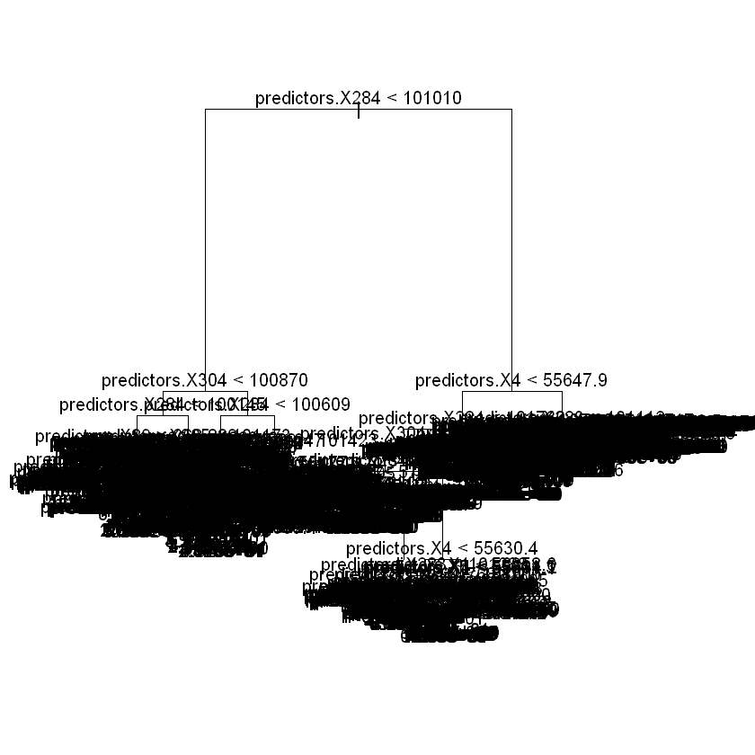

```r
tree.model.r = tree(y ~ ., df.r.train, mincut = 1, minsize = 2, mindev = 0)

par(bg = "white")
plot(tree.model.r); text(tree.model.r, pretty = F)
summary(tree.model.r)
```

Construyendo el árbol de regresión completo se observan 925 nodos terminales, destacando variables como X284, X304, y X4, de resto es difícil de interpretar el árbol debido a la cantidad de divisiones que se generan. Es importante mencionar que estas variables corresponden de igual forma al nivel de presión al nivel del mar y la última a la altura geopotencial.

Al igual que hicimos para el caso de la ocurrencia, tendremos que podar este árbol tan complejo. Utiliza una cross-validación con un 10-fold para encontrar el número de nodos terminales del árbol óptimo. ¿Cuál es este número? ¿Qué predictores aparecen como los más importantes?

Para la poda de un árbol de regresión es importante analizar un equilibrio entre ajuste y complejidad del modelo al igual que se hizo anteriormente para el árbol de clasificación. En este sentido buscaremos el equilibrio entre el RSS (Residual Sum of Squares) y el número de hojas, a través de la siguiente grafica.

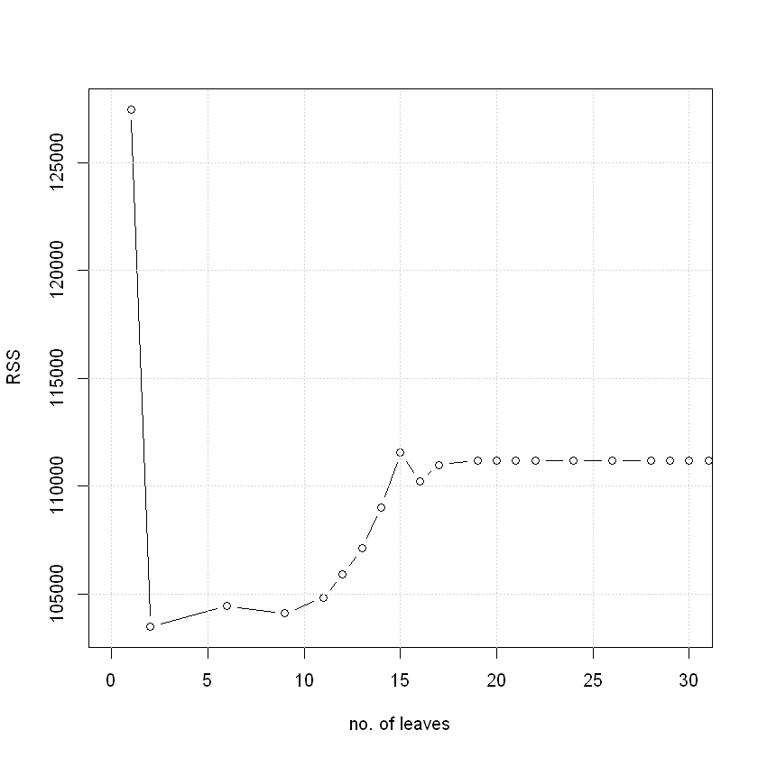

```r
set.seed(2103)
t.cv.r = cv.tree(tree.model.r, K = 10)
par(bg = "white")
plot(t.cv.r$size, t.cv.r$dev, type = "b", xlim = c(0, 30),
     xlab = "no. of leaves", ylab = "RSS")
grid()
```

```
Regression tree:
snip.tree(tree = tree.model.r, nodes = c(7L, 13L, 24L, 51L, 2L
))
Variables actually used in tree construction:
[1] "predictors.X284" "predictors.X4"   "predictors.X304"
Number of terminal nodes:  6
Residual mean deviance:  23.2 = 86850 / 3744
Distribution of residuals:
   Min. 1st Qu.  Median    Mean 3rd Qu.    Max.
-9.4230 -1.0680 -0.3197  0.0000 -0.3197 56.4800
```

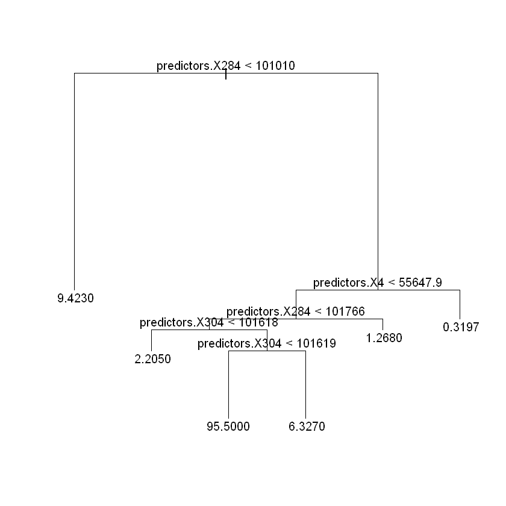

```r
tree.model.opt.r = prune.tree(tree.model.r, best = 6)
par(bg = "white")
plot(tree.model.opt.r); text(tree.model.opt.r, pretty = F)
summary(tree.model.opt.r)
```

Con 6 nodos terminales se observa que las variables predictoras más importantes son X284, X304 y X4. De igual manera se observa variables asociadas a la presión al nivel del mar, y altura geopotencial. Adicionalmente, se observa que el Residual mean deviance aumentó con respecto al arbol completo, debido a lo explicado anteriormente, estamos perdiendo un poco de precisión en el modelo a favor de generar un modelo más simple y que generalice mejor (comparándolo con el modelo completo que es un modelo sobreajustado). Esto está estrechamente relacionado con que estamos usando menos nodos terminales.

Ahora bien, se observa que las variables X284 y X304 se repiten para generar las particiones de los nodos, por lo cual se puede inferir que son variables importantes a la hora de predecir la precipitación.

Con este árbol de regresión óptimo vamos a predecir en el test, y conserva la predicción obtenida.

```r
pred.tree.r = predict(tree.model.opt.r, df.r.test)
```

Repite el mismo proceso para el segundo árbol de regresión (el que sólo se entrena sobre los días de lluvia en el train).

```r
#Construccion de dataframe para train solo lluvia
df.r.train.lluvia = df.r.train[which(df.r.train$y >= 1), ]

dim(df.r.train.lluvia)
```

1. 761

2. 38

Es importante observar que al filtrar los días de lluvia del dataframe de trabajo se hace una reducción considerable de valores, por lo cual se infiere que la cantidad de días de lluvia del dataframe de trabajo de los modelos anteriores tenían muchos días sin lluvia y pocos días con lluvia. Esto es de esperarse de acuerdo con lo observado en la exploración de datos.

Primero se construye el árbol completo partiendo de la misma configuración explicada anteriormente.

```
Regression tree:
tree(formula = y ~ ., data = df.r.train.lluvia, mincut = 1, minsize = 2,
    mindev = 0)
Number of terminal nodes:  599
Residual mean deviance:  0.01553 = 2.516 / 162
Distribution of residuals:
   Min. 1st Qu.  Median    Mean 3rd Qu.    Max.
-0.2000  0.0000  0.0000  0.0000  0.0000  0.1667
```

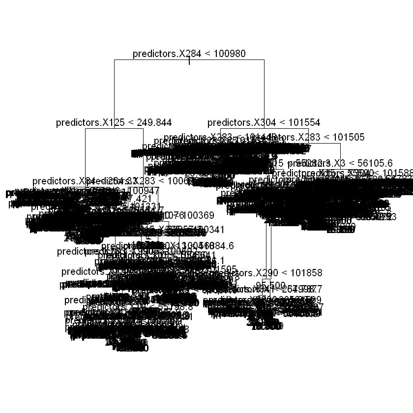

```r
tree.model.r.lluvia = tree(y ~ ., df.r.train.lluvia, mincut = 1, minsize = 2, mindev = 0)

par(bg = "white")
plot(tree.model.r.lluvia); text(tree.model.r.lluvia, pretty = F)
summary(tree.model.r.lluvia)
```

En el árbol de regresión completo de solo los registros de lluvia se observa que se generan 599 nodos terminales, destacando variables como X284, X125, X304 y X283, de resto es difícil de interpretar el árbol debido a la cantidad de divisiones que se generan. Es importante mencionar que estas variables corresponden de igual forma al nivel de presión al nivel del mar y una de ellas a temperatura del aire. Adicionalmente, se destaca la variable X284, la cual se considera importante a lo largo de los árboles que se han realizado hasta ahora; y se resalta la variable X304 debido a que permanecen ambas al momento de filtrar solo lluvia. Estas hacen referencia ala presión a nivel del mar.

De igual manera, la cantidad de nodos terminales es bastante alta si comparamos con el modelo binario, lo cual puede deberse a la naturaleza de la variable objetivo como se mencionó anteriormente. Sin embargo, vemos que este número se reduce con respecto al modelo completo de regresión donde se contemplan todos los datos (no solo los asociados a la lluvia), lo cual puede deberse a que ciertas variables ya no cobran relevancia cuando hay lluvia, además de que el criterio de división se simplifica.

Se realiza la cross-validation de 10-folds para encontrar el número de nodos terminales del árbol óptimo para este caso.

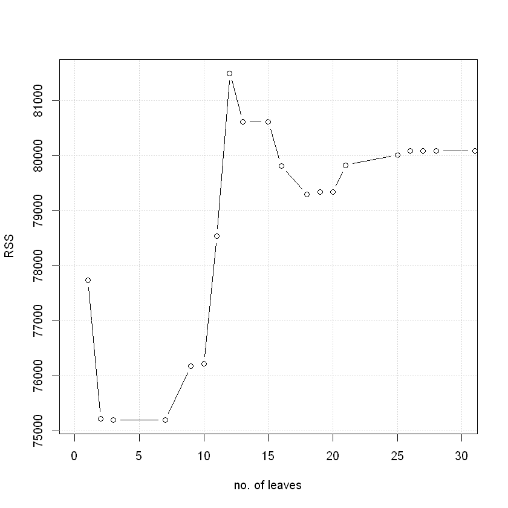

```r
set.seed(213)
t.cv.r.lluvia = cv.tree(tree.model.r.lluvia, K = 10)
par(bg = "white")
plot(t.cv.r.lluvia$size, t.cv.r.lluvia$dev, type = "b", xlim = c(0, 30),
     xlab = "no. of leaves", ylab = "RSS")
grid()
```

En la gráfica se puede observar un comportamiento ascendente entre el RSS y el número de hojas, esto podría deberse a que al filtrar por días de lluvia la variabilidad del dataset aumenta causando que las divisiones sean menos útiles a la hora de reducir el RSS, siendo los parámetros de mincut, minsize y mindev muy permisivos. Es importante mencionar que al filtrar los días de lluvia solo tenemos valores con precipitaciones mayores que 1 mm, por lo cual la variabilidad del dataset no va a estar sesgada por lo valores cercanos a cero de días de no lluvia, sino que estará enfocada en los valores reales de precipitación cuando llueve. También es importante observar que la muestra de train disminuye lo que podría afectar la estabilidad.

Ahora bien, se observa unos valores mínimos entre 4 y 7 hojas, por lo cual se toman 4 hojas partiendo del principio de análisis de la métrica RSS, buscando compensar la relación ajuste/complejidad, debido a que se observa un valor bajo de RMS donde se estabiliza un poco, y luego sigue un comportamiento creciente.

```
Regression tree:
snip.tree(tree = tree.model.r.lluvia, nodes = c(6L, 29L, 4L,
15L, 56L, 5L))
Variables actually used in tree construction:
[1] "predictors.X284" "predictors.X125" "predictors.X304" "predictors.X283"
[5] "predictors.X15"  "predictors.X5"
Number of terminal nodes:  7
Residual mean deviance:  77.64 = 58540 / 754
Distribution of residuals:
   Min. 1st Qu.  Median    Mean 3rd Qu.    Max.
-14.670  -4.827  -2.443   0.000   2.857  50.370
```

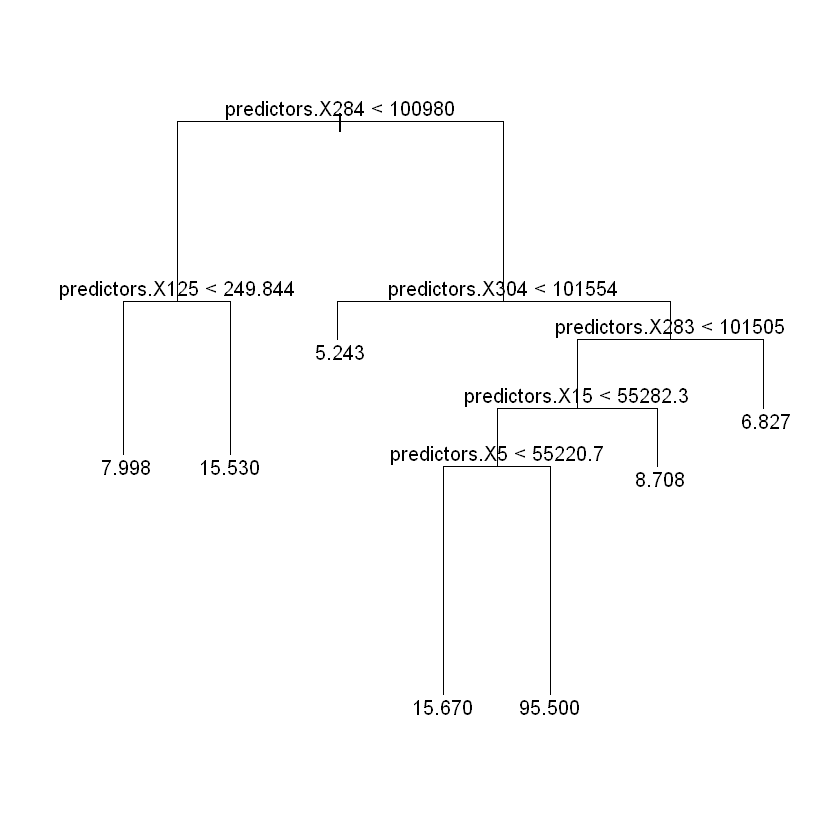

```r
tree.model.opt.r.lluvia = prune.tree(tree.model.r.lluvia, best = 4)
par(bg = "white")
plot(tree.model.opt.r.lluvia); text(tree.model.opt.r.lluvia, pretty = F)
summary(tree.model.opt.r.lluvia)
```

Los resultados del árbol podado muestran que las variables más importantes son "predictors.X284", "predictors.X125", "predictors.X304", "predictors.X283", "predictors.X15" y "predictors.X5". De igual manera se observa variables asociadas a la presión al nivel del mar, y altura geopotencial, y una nueva variable relacionada con la temperatura del aire. Ahora bien, se destaca la variable X284 la cual ha sido fundamental para los modelos realizado; y se destaca X304, la cual es una variable que coincide con el modelo óptimo con todos los valores de entrenamiento. Esto quiere decir que estas dos variables son importantes para eventos de lluvia. También se observa un el Residual Mean Deviance bastante elevado dando una información preliminar de un modelo poco preciso.

Por su parte, se observa que se configuro un árbol de 4 nodos terminales pero se generó de 7, lo cual puede deberse a cómo la función prune.tree realiza la optimización para garantizar un equilibrio entre la simplicidad del modelo y el error residual. Basado en el error asociado a los nodos terminales la función puede decidir si dividir o agrupar para cumplir los parámetros mínimos para generar un modelo simple y con error residual bajo. Además, es posible que la variabilidad de los datos haga que el árbol se extienda para ajustarse mejor a los datos de lluvia.

Con este árbol de regresión entrenada con el dataframe de lluvia vamos a predecir en el test, y conserva la predicción obtenida.

```r
pred.tree.r.lluvia = predict(tree.model.opt.r.lluvia, df.r.test)
```

Ahora se obtienen las series predichas completas para los modelos de regresión, y se valida los resultados en función de las métricas.

```r
#serie completa para modelo entrenado con todo el dataset de train
pred.comp.r = (as.numeric(as.character(pred.tree.1))) * pred.tree.r

#RMSE
# calculo de RMSE
rmse = function(x, y) {
    sqrt(mean((x - y)^2))}

rmse.comp.r = rmse(pred.comp.r, df.r.test$y)

#ratio de varianza
rv.tree.comp.r = var(pred.comp.r) / var(df.r.test$y)

#Correlación de spearman
cor.compl.r = cor(df.r.test$y, pred.comp.r, method = "spearman")

cat("Modelo regresión tree precipitación", "\n")
cat("RMSE: ", rmse.comp.r, "\n")
cat("rv: ", rv.tree.comp.r, "\n")
cat("Correlación de spearman: ", cor.compl.r, "\n")
```

[output not shown]

Los resultados muestran un RMSE de 4.4 aproximadamente, que corresponde al error promedio en las predicciones del modelo en las unidades de la variable objetivo (precipitación), lo cual indica que en promedio las predicciones están a 4.4 mm de distancia de los valores reales. Este valor podría no ser tan bueno considerando la métrica de lluvias y no lluvia es 1mm. Ahora bien, recordemos que los datos de entrenamiento tenían muchos ceros (días sin lluvia) y que había datos atípicos con precipitaciones bastante altas (pocas), lo que afecta a la métrica.

De igual manera, rv muestra que el 34% de la variación de la precipitación es explicado por el modelo, lo cual es bajo, indicando que el modelo subestima la variabilidad de los datos reales. Sin embargo, se observa una correlación moderada de Spearman de 0.61, lo cual indica una correlación positiva moderada entre las predicciones del modelo y los valores reales. En términos generales hay un modelo de capacidad predictiva pero que puede mejorar debido a que es poca la variación explicada por el modelo.

```r
#serie completa para modelo entrenado con dataset de train solo lluvia
pred.comp.r.lluvia = (as.numeric(as.character(pred.tree.1))) * pred.tree.r.lluvia

#RMSE
rmse.comp.r.lluvia = rmse(pred.comp.r.lluvia, df.r.test$y)

#ratio de varianza
rv.tree.comp.r.lluvia = var(pred.comp.r.lluvia) / var(df.r.test$y)

#Correlación de spearman
cor.compl.r.lluvia = cor(df.r.test$y, pred.comp.r.lluvia, method = "spearman")

cat("Modelo regresión tree precipitación solo lluvia", "\n")
cat("RMSE: ", rmse.comp.r.lluvia, "\n")
cat("rv: ", rv.tree.comp.r.lluvia, "\n")
cat("Correlación de spearman: ", cor.compl.r.lluvia, "\n")
```

[output not shown]

Los resultados muestran un RMSE de 4.9 aproximadamente, que corresponde al error promedio en las predicciones del modelo en las unidades de la variable objetivo (precipitación), lo cual indica que en promedio las predicciones están a 4.9 mm de distancia de los valores reales, lo cual es parecido al modelo de regresión del dataframe de train completo con un ligero incremento. En cuanto al rv se observa que es 72% aproximadamente, indicando una buena explicación de la variación de la precipitación por parte del modelo. Finalmente, la correlación de Spearman se mantiene con respecto al modelo anterior, lo cual indica una correlación positiva moderada entre las predicciones del modelo y los valores reales. Este modelo muestra una buena explicación de la variación de precipitación con un error de predicciones un poco mas alto.

Pregunta: ¿Cuál de los dos árboles da mejores resultados? ¿Por qué?

```r
# matriz tabla resumen
result.r.tree = matrix(c(rmse.comp.r, rv.tree.comp.r, cor.compl.r, rmse.comp.r.lluvia, rv.tree.comp.r.lluvia, cor.compl.r.lluvia), nrow = 2, byrow = T)
colnames(result.r.tree) = c("RMSE", "rv", "Correlación")
rownames(result.r.tree) = c("R.Tree completo", "R.Tree lluvia")
result.r.tree
```

A matrix: 2 × 3 of type dbl

|  | RMSE | rv | Correlación |
| --- | --- | --- | --- |
| R.Tree completo | 4.486581 | 0.3409243 | 0.6147733 |
| R.Tree lluvia | 4.926077 | 0.7201311 | 0.6115594 |

Los resultados arrojan métricas similares para ambos árboles en las métricas de RMSE y correlación, indicando por un lado un valor un poco alto en cuento al error de las predicciones, siendo más sensible el modelo entrenado con los valores de solo lluvia. Es importante recordar que esta métrica se ve afecta por los valores de precipitación extrema, afectando a los modelos ya que podría tener dificultades tanto para predecir valores extremos como para ajustar con precisión valores de baja precipitación. Por otro lado, mantienen una correlación positiva moderada, en la cual se captura los patrones y tendencia en general.

La diferencia en los modelos está en el rv, para el cual el modelo entrenado solo con los eventos de lluvia muestra una mejora significativa en la capacidad explicativa de la variación de la precipitación por parte del modelo (modelo solo lluvia captura mejor la variabilidad de los datos). Es decir que el modelo entrenado con los valores de precipitación de lluvia puede tener un poco más de rango en el error de la predicción, pero es un modelo que logra explicar mejor la precipitación. Este incremento podría deberse a que, al eliminar los días sin lluvia, el modelo se concentra en patrones más específicos de precipitación (reduce el ruido al excluir los valores de cero), aunque esto resulte en un RMSE algo mayor por la variabilidad que puede haber de estos datos, debido a que se hacen más significativos los valores extremos (se recude dataframe). Con esto, podría decirse que comparando estos dos modelos el mejor sería el entrenado con los eventos de lluvia.

Ahora bien, hay que considerar las limitaciones de los árboles para estabilizar modelos por su sensibilidad al cambio en los datos. Los árboles simples dividen el espacio de características en regiones rectangulares, lo cual puede ser demasiado rígido para capturar los patrones no lineales y complejos, por lo cual usar métodos de ensambles como Random Forests podría generar un modelo que capture mejor las relaciones. Además, cambios en los datos puede llevar a una estructura completamente diferente del árbol, afectando directamente el ratio de varianza y otras métricas. La solución a este aspecto podría ser usar muchos árboles que estabilicen el modelo.

## Random forests (2.5 puntos)

A continuación vamos a realizar el mismo ejercicio pero sustituyendo árboles individuales por random forests, empleando para ello en este ejercicio la técnica de “bagging”. Empecemos con el evento ocurrencia. Para estimar cuál sería el tamaño óptimo de nuestro random forest, prueba bosques de hasta 1000 árboles (utiliza la función randomForest) y plotea los errores “Out-Of-Bag” (OOB). ¿Con cuántos árboles te quedarías?

```r
#dataset para evento de ocurrencia de lluvia
df.train.1.rf = df.occ.1[ind.train, ]
df.test.1.rf = df.occ.1[indtest, ]
```

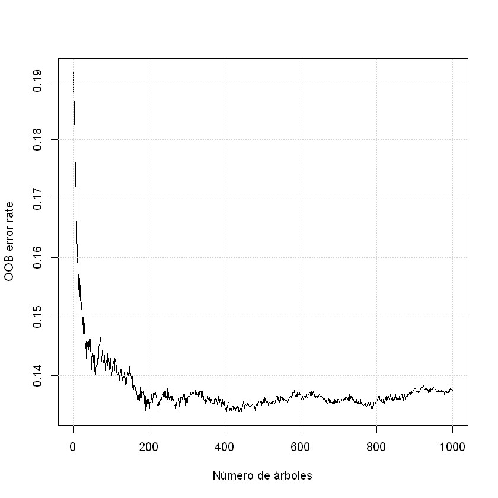

```r
# Entrenar el Random Forest
set.seed(213)
rf.model = randomForest(y ~ ., data = df.train.1.rf, ntree = 1000)
# Ploteo de los errores OOB
par(bg = "white")
plot(rf.model$err.rate[, 1], type = "l", xlab = "Número de árboles", ylab = "OOB error rate")
grid()
```

```r
which.min(rf.model$err.rate[, 1])
```

403

Partiendo de la gráfica de OOB rate versus el número de árboles, se puede considerar un número óptimo de árboles alrededor de 200. Este es el punto donde el error OOB se estabiliza, lo que indica que agregar más árboles no genera una mejora significativa en la reducción del error ni en la capacidad predictiva del modelo. Es importante recordar que esta gráfica muestra una estimación del error de prueba que se puede esperar si se utiliza un modelo con esa cantidad de árboles, lo cual nos ayuda a evitar el sobreajuste y garantizar una generalización adecuada. Por su parte, si se ejecuta la funcion which.min, se observa un valor mas elevado de 403, el cual no sería necesario partiendo de que la diferencia no es significativa.

**Nota:** Hemos visto en la teoría que además del número de árboles, el otro parámetro a ajustar en los random forests es el número de predictores que se consideran en cada nodo para el splitting. En este ejemplo utlizaremos los valores típicos; n−−√ en problemas de clasificación y n/3 en problemas de predicción (siendo n el número total de predictores disponibles).

Para seguir definiendo los parámetros optimos del modelo Ramdom Forest, es importante considerar el parámetro mtry para definir el número de variables a considerar a la hora de construir los árboles, siendo menor al número total para garantizar de que los árboles sean diferentes y no se genere sobreajuste y de igual forma no sean tan pequeño para no generar arboles simples que no capturen la variabilidad de los datos.

Se construye el modelo optimo con el número de árboles y predictores indicados, el cual es 6.

```r
round(sqrt(ncol(df.train.1.rf[, -1])))
```

6

```r
set.seed(2103)
rf.model.op = randomForest(y ~ ., data = df.train.1.rf, ntree = 200, mtry = round(sqrt(ncol(df.train.1.rf[, -1]))))
```

Utiliza el bosque de tamaño óptimo parar predecir la ocurrencia en el test, y conserva la predicción.

```r
pred.rf.1 = predict(rf.model.op, df.test.1.rf)

#accuracy
acc.rf.1 = acc.class(pred.rf.1, df.test.1.rf$y)

cat("Accuracy modelo random forest para ocurrencia: ", acc.rf.1, "\n")
cat("Accuracy modelo tree para ocurrencia: ", acc.tree.1, "\n")
```

[output not shown]

La predicción del modelo optimo con Random Forest arroja unos resultados de accuracy en test de 87% aproximadamente, que representa el porcentaje de predicciones correctas realizadas por el modelo. Si comparamos con el rendimiento del modelo del árbol de clasificación individual vemos que el modelo mejora, pero no de manera significativa. Sin embargo, el uso de Random Forest aporta ventajas importantes más allá del aumento en el accuracy. Este método reduce la volatilidad inherente a los árboles individuales, ya que combina múltiples árboles para suavizar los efectos de posibles divisiones erróneas o datos atípicos. En otras palabras, el modelo es más robusto y tiene menor riesgo de sobreajuste al conjunto de entrenamiento.

Seguidamente, tal y como hicimos con los árboles individuales, vamos a crear dos random forests para la cantidad, uno que se entrene sobre todo el dataset de train y otro que se entrene sólo sobre los días de lluvia (en el train). De nuevo, tendrás que estimar cuál es el número óptimo de árboles en cada uno de ellos (prueba bosques de hasta 1000 árboles). ¿Qué tamaños óptimos obtienes?

Primero empezamos con el modelo de regresión con Ramdom Forest para todo el dataset de train. Determinamos los parámetros óptimos de número óptimo de árboles y definimos el mtry acorde a lo indicado.

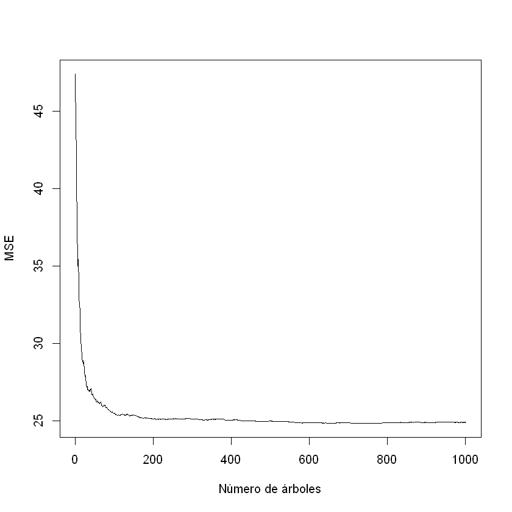

```r
#hallando el número optimo de arboles
set.seed(2103)
rf.model.r = randomForest(y ~ ., data = df.r.train, ntree = 1000)

par(bg = "white")
plot(rf.model.r$mse, type = "l", xlab = "Número de árboles", ylab = "MSE")
```

```r
which.min(rf.model.r$mse)
```

724

En la gráfica de Mean Squared Error (MSE) por el número de árboles se observa que el error disminuye hasta estabilizarse en un valor alrededor de 200 árboles, donde el incremento de estos no mejora significativamente el error. Recordemos que el MSE es una medida que estipula el promedio del error cuadrático de las predicciones de un modelo, lo cual da una idea de que tan bien el modelo predice los valores reales de la variable objetivo. Si se consulta el valor más bajo generado en el modelo se tiene que se alcanza el MSE mínimo en 724 árboles, sin embargo, no hay una disminución significativa en el error que se logra observar entre estos valores de árboles, por lo cual no es eficiente computacionalmente incluir más árboles si no se contribuyen a mejorar el rendimiento del modelo.

Se construye el modelo optimo con el número de arboles y predictores indicados, el cual es 12.

```r
round(ncol(df.r.train[, -1])/3)
```

12

```r
set.seed(2103)
rf.model.r.op = randomForest(y ~ ., data = df.r.train, ntree = 200, mtry = round(ncol(df.r.train[, -1])/3))
```

Utiliza los bosques óptimos encontrados para predecir la cantidad en el test, y conserva las predicciones obtenidas.

```r
pred.rf.r = predict(rf.model.r.op, df.r.test)
```

Ahora construyamos el modelo de regresión con Ramdom Forest para el dataset de lluvia. Determinamos los parámetros óptimos de número de arboles y definimos el mtry acorde a lo indicado.

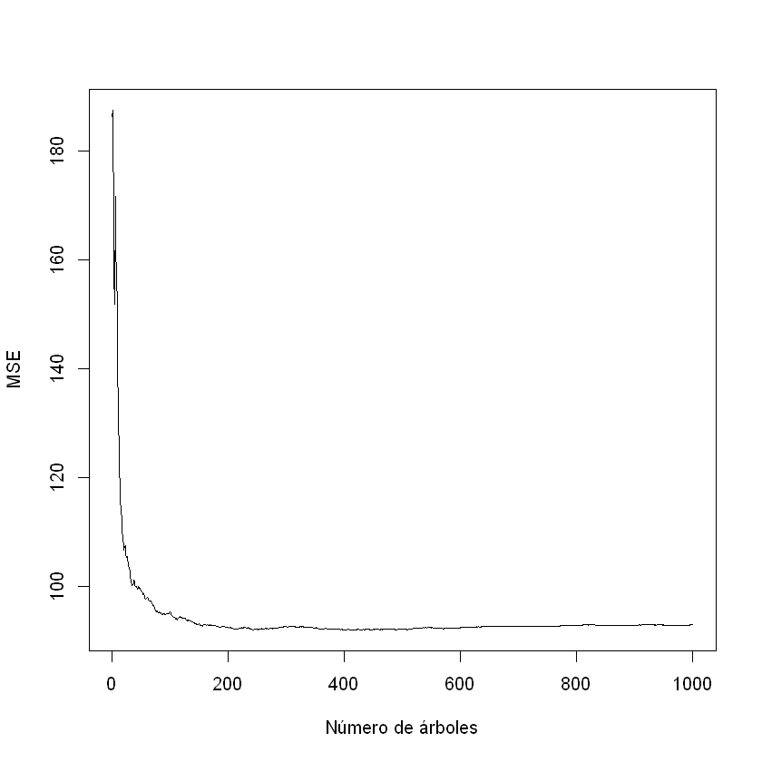

```r
set.seed(2103)
rf.model.r.lluvia = randomForest(y ~ ., data = df.r.train.lluvia, ntree = 1000)
par(bg = "white")
plot(rf.model.r.lluvia$mse, type = "l", xlab = "Número de árboles", ylab = "MSE")
```

```r
which.min(rf.model.r.lluvia$mse)
```

400

Los resultados muestran que el valor más bajo de MSE es 400, sin embargo, este valor es muy alto y no representa una mejora significativa en el error, por lo cual se decide tomar un valor de 200 árboles de tal manera que se garantice un MSE bajo, un buen rendimiento del modelo y eficiencia computacional.

Se construye el modelo optimo con el número de árboles y predictores indicados.

```r
set.seed(2103)
rf.model.r.op.lluvia = randomForest(y ~ ., data = df.r.train.lluvia, ntree = 200, mtry = round(ncol(df.r.train.lluvia[, -1])/3))
```

Se predice en test y se guardan los resultados para posteriores análisis.

```r
pred.rf.r.lluvia = predict(rf.model.r.op.lluvia, df.r.test)
```

Construye las predicciones completas (ocurrencia×cantidad) de test y valídalas en función de las mismas métricas utilizadas en el apartado anterior.

```r
# predicción completa para modelo entrenado con todo el dataset de train
pred.rf.r.completo = as.numeric(as.character(pred.rf.1)) * pred.rf.r
```

```r
#metricas
#RMSE
rmse.rf.r.completo = rmse(pred.rf.r.completo, df.r.test$y)

#ratio de varianza
rv.rf.r.completo = var(pred.rf.r.completo) / var(df.r.test$y)

#Correlación Spearman
cor.rf.r.completo = cor(df.r.test$y, pred.rf.r.completo, method = "spearman")


cat("Modelo regresion Random Forest precipitación", "\n")
cat("RMSE: ", rmse.rf.r.completo, "\n")
cat("rv: ", rv.rf.r.completo, "\n")
cat("Correlación Spearman: ", cor.rf.r.completo, "\n")
```

```
Modelo regresion Random Forest precipitación
RMSE:  4.312477
rv:  0.4529322
Correlación Spearman:  0.6086981
RMSE:  4.312477
rv:  0.4529322
Correlación Spearman:  0.6086981
```

En el modelo de regresión de Random Forest se observa un RMSE que indica que en promedio las predicciones están a 4.3 mm de distancia de los valores reales lo cual es parecido al comportamiento observado en el árbol individual. Se observa una métrica con un resultado moderado del ratio de varianza, con un 45% de explicación de la variación de la precipitación por parte del modelo. Además, se observa un indicador consistente en la correlación de las predicciones del modelo y los valores reales, indicando una relación positiva.

```r
#predicción completa de solo lluvia para modelo random forest
pred.rf.r.completo.lluvia = as.numeric(as.character(pred.rf.1)) * pred.rf.r.lluvia

#metricas
#RMSE
rmse.rf.r.lluvia.completo = rmse(pred.rf.r.completo.lluvia, df.r.test$y)

#ratio de varianza
rv.rf.r.lluvia.completo = var(pred.rf.r.completo.lluvia) / var(df.r.test$y)

#Correlación Spearman
cor.rf.r.lluvia.completo = cor(df.r.test$y, pred.rf.r.completo.lluvia, method = "spearman")

cat("Modelo regresion Random Forest precipitación solo lluvia", "\n")
cat("RMSE: ", rmse.rf.r.lluvia.completo, "\n")
cat("rv: ", rv.rf.r.lluvia.completo, "\n")
cat("Correlación Spearman: ", cor.rf.r.lluvia.completo, "\n")
```

```
Modelo regresion Random Forest precipitación solo lluvia
RMSE:  4.550188
rv:  0.6802172
Correlación Spearman:  0.6037957
RMSE:  4.550188
rv:  0.6802172
Correlación Spearman:  0.6037957
```

En cuanto a los resultados del modelo entrenado solo con los eventos de lluvia se observa resultados similares al modelo con el dataframe de entrenamiento completo, donde el RMSE y la correlación no presentan una diferencia significativa, sin embargo, si se evidencia una mejora en el rv del modelo entrenado solo con datos de lluvia, mostrando un valor más consistente en el porcentaje de generalización del modelo (68%). Esto seguramente se debe a las razones similares que se analizaron en los árboles individuales, donde la eliminación del ruido de días sin lluvia permite que el entrenamiento del modelo sea mucho mejor pese a que se reduce el dataset de entrenamiento. Hay un poco más de error en las predicciones (RMSE), pero con un mejor ajuste (rv) que el modelo completo de Random Forest.

El aumento en RMSE puede deberse a que el modelo predice valores cercanos a cero en días no lluvioso de test, debido a que solo esta entrenado para eventos con lluvia, esto hace que la variabilidad incremente, aumentando el error. Además, es importante recordar que los valores atípicos afectan en términos generales esta métrica.

Pregunta: ¿Qué conclusiones obtienes de la comparación entre árboles individuales y random forests?

```r
#matriz tabla resumen
result.rf.r = matrix(c(rmse.rf.r.completo, rv.rf.r.completo, cor.rf.r.completo, rmse.rf.r.lluvia.completo, rv.rf.r.lluvia.completo, cor.rf.r.lluvia.completo), nrow = 2, byrow = T)
colnames(result.rf.r) = c("RMSE", "rv", "Correlación")
rownames(result.rf.r) = c("R.Forest completo", "R.Forest lluvia")
result.rf.r
result.r.tree
```

A matrix: 2 × 3 of type dbl

|  | RMSE | rv | Correlación |
| --- | --- | --- | --- |
| R.Forest completo | 4.312477 | 0.4529322 | 0.6086981 |
| R.Forest lluvia | 4.550188 | 0.6802172 | 0.6037957 |

A matrix: 2 × 3 of type dbl

|  | RMSE | rv | Correlación |
| --- | --- | --- | --- |
| R.Tree completo | 4.486581 | 0.3409243 | 0.6147733 |
| R.Tree lluvia | 4.926077 | 0.7201311 | 0.6115594 |

En cuanto al ratio de varianza es donde se observa la mayor variación. Para los modelos del dataset completo de train se observa que al implementar múltiples árboles hay una mejora en la explicabilidad de la variabilidad de precipitación por parte del modelo, esto debido a que la combinación de predicciones de múltiples arboles ayuda a capturar mejor los patrones de los datos (pasa de 0.34 a 0.45). Además, recordemos que al reducir el número de variables (mtry) aseguramos evitar sobreajuste para una mejor generalización.

Por otro lado, si comparamos esta misma métrica (rv) entre los árboles entrenados con el dataframe filtrado por lluvia se observa un comportamiento diferente, donde el modelo del árbol individual muestra un rv del 72% y Random Forest de 68%; sin embargo, hay que recordar que los árboles individuales dependen mucho de la partición de los datos y el número de variables a considerar, por lo cual son propensos a sobreajuste. Así como n esta partición se obtuvo un valor alto, en otra podría tener un ratio de varianza inferior.

Como conclusión podría decir que implementar Random Forest da como resultado unas métricas más estables, respaldadas por la generación de múltiples árboles que ayudan a capturar mejor los patrones de los datos. Pese a que no hay mucha diferencia entre el RMSE y la correlación, si es evidente que generar múltiples árboles ayuda a tener un modelo que explica adecuadamente la variabilidad de los datos.

Ahora bien, entrenar el modelo solo con los datos de lluvia permite reducir el ruido y tener un mejor entrenamiento. Con esto se obtiene un modelo con mayor capacidad explicativa de los datos (rv) pero con un poco más de error a la hora de predecir (RMSE). El aumento en RMSE puede deberse a que el modelo predice valores cercanos a cero en días no lluvioso de test, debido a que solo esta entrenado para eventos con lluvia, esto hace que la variabilidad incremente, aumentando el error. Además, hay que considerar en este aspecto los valores extremos que se identificaron en la exploración de datos y la reducción de dataset a la hora de entrenar solo con eventos de lluvia.

Finalmente, sería oportuno explorar la naturaleza de esta variable objetivo, porque vemos que los modelos tienen un RMSE recurrente alrededor de 4,4 mm (precipitación), por lo cual es un aspecto para seguir explorando.

## Modelos lineales generalizados (GLMs) (1.5 puntos)

Usaremos a continuación GLMs para el mismo problema abordado en los apartados anteriores. Como ya hemos visto en otras sesiones, debemos utilizar la familia binomial con función de enlace logit (regresión logística) para clasificación y la familia Gamma con función de enlace logarítmica para la cantidad.

Comenzamos con el modelo para la ocurrencia. Antes de entrenar el modelo es importante asegurarnos que los predictores esten estandarizados, debido a que se mejora la estabilidad en este tipo de modelos.

```r
#Escalando
x.scaled = scale(df.x)

#partición de train y test 75% y 25%
x.train.scaled = x.scaled[ind.train, ]
x.test.scaled = x.scaled[indtest, ]
```

```r
#dataframe escalado y binario
df.train.1.glm = data.frame(y = df.y.occ.1[ind.train], x.train.scaled)
df.test.1.glm = data.frame(y = df.y.occ.1[indtest], x.test.scaled)
```

Seguimos con el entrenamiento del modelo para ocurrencia teniendo en cuenta la función de enlace logit (regresión logística) para clasificación.

```r
# Entrenar el modelo de regresión logística
glm.model.1 = glm(y ~ ., data = df.train.1.glm, family = binomial(link = "logit"))

summary(glm.model.1)
```

```
Call:
glm(formula = y ~ ., family = binomial(link = "logit"), data = df.train.1.glm)

Coefficients:
             Estimate Std. Error z value Pr(>|z|)
(Intercept)  -2.36052    0.08272 -28.537  < 2e-16 ***
X1            5.26003    2.39224   2.199  0.02789 *
X2           -3.89798    5.83565  -0.668  0.50416
X3           -4.18444    7.55870  -0.554  0.57986
X4           14.80929    7.15652   2.069  0.03851 *
X5           -8.41919    4.50919  -1.867  0.06189 .
X6           -4.61218    2.57629  -1.790  0.07342 .
X7           -1.12365    7.28035  -0.154  0.87734
X8           15.28419   11.21894   1.362  0.17309
X9          -30.66212   13.28403  -2.308  0.02099 *
X10          14.34873   10.86126   1.321  0.18647
X12           4.46059    4.12386   1.082  0.27941
X13          -7.94477    9.26614  -0.857  0.39122
X14          23.67658   13.87024   1.707  0.08782 .
X15         -15.09761   13.20676  -1.143  0.25297
X18          -0.26285    4.75265  -0.055  0.95589
X19          -6.71570   10.49243  -0.640  0.52214
X20           7.60084   10.12854   0.750  0.45299
X24          -1.63877    4.23459  -0.387  0.69876
X25          -0.28929    3.96204  -0.073  0.94179
X83          -4.57646    1.14476  -3.998 6.39e-05 ***
X84          -0.48369    1.36551  -0.354  0.72318
X85           1.04664    0.72252   1.449  0.14745
X88           1.56662    1.07791   1.453  0.14611
X89           0.37215    1.18050   0.315  0.75257
X125          0.43344    0.25661   1.689  0.09120 .
X283         -1.22126    0.72207  -1.691  0.09077 .
X284         -7.69198    1.43644  -5.355 8.56e-08 ***
X285          2.52459    1.58569   1.592  0.11136
X289          6.85471    1.72055   3.984 6.78e-05 ***
X290          6.24087    3.74053   1.668  0.09523 .
X294         -2.69062    2.04097  -1.318  0.18740
X295        -13.66312    4.83055  -2.828  0.00468 **
X299          1.41141    1.95150   0.723  0.46953
X300          9.29790    4.46370   2.083  0.03725 *
X304          0.54072    1.13399   0.477  0.63348
X305         -4.49544    3.09810  -1.451  0.14677
X310          1.41772    1.27857   1.109  0.26750
---
Signif. codes:  0 '***' 0.001 '**' 0.01 '*' 0.05 '.' 0.1 ' ' 1

(Dispersion parameter for binomial family taken to be 1)

    Null deviance: 3783.3  on 3749  degrees of freedom
Residual deviance: 2173.5  on 3712  degrees of freedom
AIC: 2249.5

Number of Fisher Scoring iterations: 6
```

En el summary del modelo es posible identificar algunas variables que son relevantes para determinar la variable objetivo, como es el caso de X284, X289, X83, X295, X4. Recordemos que en arboles fue dominante la variable como X284, la cual tambien es importante en este modelo.

Una vez tenemos el modelo, lo utilizamos para predecir en el test. Tendremos que convertir la predicción probabilística obtenida en binaria (considera un umbral 0.5).

```r
#predecimos
pred.glm.1 = predict(glm.model.1, df.test.1.glm, type = "response")

#accuracy
outbin.test = as.double(pred.glm.1 >= 0.5)
acc.glm.1.test = acc.class(outbin.test, df.test.1.glm$y)

cat("Accuracy modelo regresión logística para ocurrencia en test: ", acc.glm.1.test, "\n")
```

```
Accuracy modelo regresión logística para ocurrencia en test:  0.8776
```

```r
conf.glm = confusionMatrix(factor(outbin.test), factor(df.test.1.glm$y))
conf.tree = confusionMatrix(factor(pred.tree.1), factor(df.occ.1$y[indtest]))
conf.rf = confusionMatrix(factor(pred.rf.1), factor(df.test.1.rf$y))

#balanced accuracy
conf.glm$byClass["Balanced Accuracy"]
conf.tree$byClass["Balanced Accuracy"]
conf.rf$byClass["Balanced Accuracy"]
```

**Balanced Accuracy:** 0.76

**Balanced Accuracy:** 0.7795

**Balanced Accuracy:** 0.761

En términos de la métrica accuracy vemos un porcentaje de predicciones correctas alto, del 87% aproximadamente, el cual es muy cercano a los analizados en los resultados del árbol individual y Random Forest. Ahora bien, en la práctica anterior se identificó que este dataset se encuentra un poco sesgado, por lo cual validar solo esta métrica no es suficiente para conocer un poco más el rendimiento de los modelos. Al crear la matriz de confusión y consultar el Acurracy balanceado, vemos que de igual manera todos los modelos presentan un buen rendimiento, donde hacen una adecuada separación de clases. Hay otras métricas a analizar, como la curva ROC pero no es el enfoque de estudio en este caso.

Es importante notar que el balanced accuracy evalúa el rendimiento de cada clase de forma igualitaria, lo que lo convierte en una métrica más robusta cuando las clases tienen tamaños desiguales. Este valor es un buen indicador de que el modelo está manejando correctamente tanto las clases mayoritarias como las minoritarias.

A continuación, ajustamos el modelo de cantidad. Para ello tenemos que seleccionar previamente los días de lluvia (la familia Gamma sólo acepta valores positivos).

```r
#dataframe con valores escalado de x
df.train.glm = data.frame(y = df.y[ind.train], x.train.scaled)
df.test.glm = data.frame(y = df.y[indtest], x.test.scaled)
```

```r
#solo lluvia
df.train.glm.l = df.train.glm[which(df.train.glm$y >= 1), ]
```

Seguimos con el entrenamiento del modelo para cantidad de precipitación teniendo en cuenta la familia Gamma con función de enlace logarítmica.

```r
# Entrenar el modelo de regresión logística
glm.model.l = glm(y ~ ., data = df.train.glm.l, family = Gamma(link = "log"))

summary(glm.model.l)
```

```
Call:
glm(formula = y ~ ., family = Gamma(link = "log"), data = df.train.glm.l)

Coefficients:
             Estimate Std. Error t value Pr(>|t|)
(Intercept)   1.65280    0.06948  23.787   <2e-16 ***
X1            1.59706    1.50347   1.062   0.2885
X2           -1.47297    3.37600  -0.436   0.6627
X3           -2.19886    4.24484  -0.518   0.6046
X4            1.41388    3.93735   0.359   0.7196
X5           -4.09059    2.45634  -1.665   0.0963 .
X6           -0.58256    1.72156  -0.338   0.7352
X7            1.06635    4.31034   0.247   0.8047
X8           10.60571    6.49190   1.634   0.1028
X9           -3.72969    7.43911  -0.501   0.6163
X10           7.59347    5.98395   1.269   0.2049
X12          -2.16021    2.72182  -0.794   0.4277
X13         -11.45988    5.53643  -2.070   0.0388 *
X14           2.62705    8.10996   0.324   0.7461
X15          -9.78795    7.49644  -1.306   0.1921
X18           7.43391    2.90397   2.560   0.0107 *
X19           2.34120    6.49274   0.361   0.7185
X20           4.79562    5.89122   0.814   0.4159
X24          -4.92023    2.58143  -1.906   0.0570 .
X25           0.59911    2.31735   0.259   0.7961
X83          -0.12346    0.78437  -0.157   0.8750
X84          -0.67789    0.88733  -0.764   0.4451
X85           0.98977    0.47590   2.080   0.0379 *
X88          -0.50945    0.70951  -0.718   0.4730
X89          -0.08185    0.75929  -0.108   0.9142
X125          0.42700    0.16444   2.597   0.0096 **
X283         -1.55707    0.45175  -3.447   0.0006 ***
X284         -0.27981    0.91372  -0.306   0.7595
X285          0.83028    0.92351   0.899   0.3689
X289          0.94375    1.14044   0.828   0.4082
X290         -1.99616    2.00488  -0.996   0.3198
X294         -0.35776    1.31650  -0.272   0.7859
X295          4.61558    2.71059   1.703   0.0890 .
X299          0.19281    1.21552   0.159   0.8740
X300         -4.92839    2.64492  -1.863   0.0628 .
X304          0.55627    0.68311   0.814   0.4157
X305          3.20406    1.88022   1.704   0.0888 .
X310         -1.23460    0.76944  -1.605   0.1090
---
Signif. codes:  0 '***' 0.001 '**' 0.01 '*' 0.05 '.' 0.1 ' ' 1

(Dispersion parameter for Gamma family taken to be 0.8561917)

    Null deviance: 761.51  on 760  degrees of freedom
Residual deviance: 540.71  on 723  degrees of freedom
AIC: 4657.2

Number of Fisher Scoring iterations: 8
```

En el summary del modelo es posible identificar algunas variables que son relevantes para determinar la variable objetivo, como es el caso de X283, X125, X18, X13, que son variables diferentes a las identificadas en el anterior, lo cual se le puede atribuir a la eliminación del ruido causado por la ausencia de precipitación al momento de filtrar solo los días de lluvia. Esto indica que la dinámica para predecir si lloverá y cuánto lloverá involucra diferentes relaciones y patrones.

Esto podría indicar que estas variables son más significativas para explicar la cantidad de precipitación cuando se sabe que esta lloviendo. Sin embargo, es importante observar que no se obtiene la variable X284, la cual en arboles fue una de las principales.

Utilizamos el modelo obtenido para predecir la cantidad en el test.

```r
pred.glm.l = predict(glm.model.l, df.test.glm, type = "response")
```

De nuevo, multiplicamos la ocurrencia por la cantidad para obtener la predicción completa en el test y la validamos en función de las métricas de validación que utilizamos para CART y random forests.

```r
## predicción completa de solo lluvia
pred.glm.l.comp.lluvia = as.numeric(as.character(outbin.test)) * pred.glm.l

#metricas
#RMSE
rmse.glm.l.comp = rmse(pred.glm.l.comp.lluvia, df.test.glm$y)

#ratio de varianza
rv.glm.l.comp = var(pred.glm.l.comp.lluvia) / var(df.test.glm$y)

#Correlación Spearman
cor.glm.l.comp = cor(df.test.glm$y, pred.glm.l.comp.lluvia, method = "spearman")

cat("Modelo GLM solo lluvia", "\n")
cat("RMSE: ", rmse.glm.l.comp, "\n")
cat("rv: ", rv.glm.l.comp, "\n")
cat("Correlación Spearman: ", cor.glm.l.comp, "\n")
```

```
Modelo GLM solo lluvia
RMSE:  4.317608
rv:  0.6833197
Correlación Spearman:  0.609189
RMSE:  4.317608
rv:  0.6833197
Correlación Spearman:  0.609189
```

Los resultados de las métricas del GLM indican un error absoluto de 4.3 mm en la predicción de cantidad de precipitación. Además, el modelo captura aproximadamente el 68% de la varianza de los datos reales (rv), el cual se considera alto partiendo de las características que se han analizado hasta el momento de este dataframe; y presenta una relación positiva moderada entre las predicciones y los valores reales. Esto significa que el modelo predice correctamente las tendencias generales.

Pregunta: Compara estos resultados con los obtenidos para CART y random forests. ¿Qué conclusiones obtienes?

```r
#resultados
resultado.glm = matrix(c(rmse.glm.l.comp, rv.glm.l.comp, cor.glm.l.comp), nrow = 1, byrow = T)
colnames(resultado.glm) = c("RMSE", "rv", "Correlación")
rownames(resultado.glm) = c("GLM solo lluvia")

resultados.acc = matrix(c(acc.tree.1, acc.rf.1, acc.glm.1.test), nrow = 1, byrow = T)
colnames(resultados.acc) = c("Tree", "Random Forest", "GLM")
rownames(resultados.acc) = c("Accuracy")

resultados.acc
resultado.glm
result.rf.r
result.r.tree
```

A matrix: 1 × 3 of type dbl

|  | Tree | Random Forest | GLM |
| --- | --- | --- | --- |
| Accuracy | 0.8656 | 0.872 | 0.8776 |

A matrix: 1 × 3 of type dbl

|  | RMSE | rv | Correlación |
| --- | --- | --- | --- |
| GLM solo lluvia | 4.317608 | 0.6833197 | 0.609189 |

A matrix: 2 × 3 of type dbl

|  | RMSE | rv | Correlación |
| --- | --- | --- | --- |
| R.Forest completo | 4.312477 | 0.4529322 | 0.6086981 |
| R.Forest lluvia | 4.550188 | 0.6802172 | 0.6037957 |

A matrix: 2 × 3 of type dbl

|  | RMSE | rv | Correlación |
| --- | --- | --- | --- |
| R.Tree completo | 4.486581 | 0.3409243 | 0.6147733 |
| R.Tree lluvia | 4.926077 | 0.7201311 | 0.6115594 |

Los resultados muestran que GLM tiene métricas similares a los modelos analizados, en particular, muy cercanas a las de Random Forest (RF). Si comparamos GLM con el modelo RF completo, observamos que ambos tienen valores de RMSE y correlaciones muy similares (aproximadamente 4.3 mm y 0.60, respectivamente). Esto indica que ambos modelos predicen con un error promedio de 4.3 mm y presentan una correlación moderada positiva entre las predicciones y los valores reales. Sin embargo, el ratio de varianza (rv) muestra una diferencia importante, donde GLM explica el 68% de la variabilidad en la precipitación, mientras que RF completo solo explica el 45%; esta diferencia podría deberse a que al eliminar los días sin lluvia (GLM), el modelo se concentra en patrones más específicos de precipitación. Esto sugiere que GLM captura mejor la dispersión de los datos reales, lo que puede reflejar un mejor ajuste a los patrones generales.

Cuando comparamos GLM con RF entrenado exclusivamente en el dataset de lluvia, el rv de ambos modelos es igual (68%), lo que indica que ambos capturan la variabilidad de los datos con la misma eficacia. De igual manera, se observa una correlación de spearman similar, indicando consistencia en la correlación de las predicciones del modelo y los valores reales. Sin embargo, hay una ligera diferencia en el RMSE (4.3 mm para GLM y 4.5 mm para RF lluvia), que puede considerarse como pequeña (0.2 mm) y no significativa en términos prácticos, pero sí evidencia que GLM tiene un desempeño un poco mejor en términos de precisión.

Ahora bien, es importante mencionar que los modelos GLM son más sencillos e interpretables a la hora de identificar predictores de mayor impacto. Como se analizó anteriormente, es posible identificar variables significativas a la hora de predecir la precipitación, pero para el caso de Random Forest este análisis es más complicado; es posible partir de un árbol individual para explorar este aspecto, pero no podríamos asegurar que las mismas variables son significativas en todas las particiones de los árboles, especialmente porque se trabaja con cantidad de variables reducida para cada partición de los árboles generados. Adicionalmente, la manera en que trabaja Random Forest hace que requiera mayor coste computacional que un GLM, debido a que dependen de la generación de múltiples árboles para garantizar una estabilidad en el modelo.

Finalmente, los árboles individuales arrojan una seria de métricas que no son del todo comparables con los otros modelos, partiendo de la naturaleza de este tipo de modelos. Estos son sensibles a los datos, por lo cual cambios en los datos puede llevar a una estructura completamente diferente del árbol, afectando las métricas. Estos árboles son un punto de partida para la interpretación de las principales variables del modelo, debido a que, a diferencia de RF, tienen una mayor interpretabilidad.

Por último, es importante destacar que los tres modelos (GLM, RF y CART) presentan valores de accuracy muy similares, con RF y GLM ligeramente superiores. Esto sugiere que cualquiera de los dos sería adecuado para tareas de predicción de lluvia, donde es importante considerar el tiempo de entrenamiento, recurso computacional e interpretabilidad.

Por su parte, sería bueno analizar el comportamiento del GLM con una menor cantidad de parámetros, debido a que los 37 parámetros podría ser un aspecto que no permita obtener un modelo con mayores capacidades. Es posible que exista correlaciones entre estos 37 parámetros que estén afectando el rendimiento del modelo. Probemos generar un modelo GLM con los predictores principales que identifiquemos.

```r
coef_table = summary(glm.model.l)$coefficients

significant_names = rownames(coef_table)[coef_table[, "Pr(>|t|)"] < 0.05]
significant_names
```

1. '(Intercept)'

2. 'X13'

3. 'X18'

4. 'X85'

5. 'X125'

6. 'X283'

```r
glm.model.l.opt = glm(y ~ X13 + X18 + X85 + X125 + X283, data = df.train.glm.l, family = Gamma(link = "log"))
```

```r
pred.glm.l.opt = predict(glm.model.l.opt, df.test.glm, type = "response")
```

```r
## predicción completa de solo lluvia
pred.glm.l.comp.opt = as.numeric(as.character(outbin.test)) * pred.glm.l.opt

#metricas
#RMSE
rmse.glm.l.comp.o = rmse(pred.glm.l.comp.opt, df.test.glm$y)

#ratio de varianza
rv.glm.l.comp.o = var(pred.glm.l.comp.opt) / var(df.test.glm$y)

#Correlación Spearman
cor.glm.l.comp.o = cor(df.test.glm$y, pred.glm.l.comp.opt, method = "spearman")

cat("Modelo GLM solo lluvia", "\n")
cat("RMSE: ", rmse.glm.l.comp.o, "\n")
cat("rv: ", rv.glm.l.comp.o, "\n")
cat("Correlación Spearman: ", cor.glm.l.comp.o, "\n")
```

[output not shown]

Además, este comportamiento subraya la posible presencia de multicolinealidad o interacciones entre las variables eliminadas, lo que podría influir negativamente en el rendimiento del modelo. Técnicas como la regularización (LASSO o Ridge), que son versiones penalizadas de los GLMs, podrían ser útiles para manejar estos problemas al seleccionar automáticamente las variables más relevantes y mejorar la generalización del modelo. No obstante, este aspecto no se explorará en el marco de este trabajo.

## k nearest neighbors (k-NN) (1.5 puntos)

La última de las técnicas a utilizar será vecinos cercanos (ten en cuenta que en este caso ya no tendremos que predecir por separado ocurrencia y cantidad). Comenzaremos por una versión de k-NN en la que sólo se considere el vecino más cercano (utiliza la función knn.reg del paquete FNN).

Nota: Recuerda que en la técnica k-NN es muy importante pre-procesar adecuadamente (estandarizar) los predictores.

Se toman los datos escalados del punto anterior y se procede a utilizar la técnica de KNN considerando el vecino más cercano. Se usa la función knn.reg partiendo de que la variable objetivo es un valor continuo (precipitación).

```r
## 1 solo vecino cercano
knn.1 = knn.reg(x.train.scaled, x.test.scaled, y = df.y[ind.train], k = 1)
str(knn.1)
```

```
List of 7
 $ call     : language knn.reg(train = x.train.scaled, test = x.test.scaled, y = df.y[ind.train],      k = 1)
 $ k        : num 1
 $ n        : int 1250
 $ pred     : num [1:1250] 0 1 35 0 0 0 2 14 7.4 9.4 ...
 $ residuals: NULL
 $ PRESS    : NULL
 $ R2Pred   : NULL
 - attr(*, "class")= chr "knnReg"
```

Como en esta técnica no se predice por separada ocurrencia y cantidad, debido a que su predicción está basada en los vecinos cercanos (en este caso 1), se procede con las métricas que se están evaluando.

```r
#outbin.knn1
outbin.knn1 = as.double(knn.1$pred >= 1)

#outbin.test.knn
outbin.test.knn = as.double(df.r.test$y >= 1)
```

```r
# validación
#RMSE
rmse.knn.1 = rmse(knn.1$pred, df.r.test$y)

#ratio de varianza
rv.knn.1 = var(knn.1$pred) / var(df.r.test$y)

#Correlación Spearman
cor.knn.1 = cor(df.r.test$y, knn.1$pred, method = "spearman")

#accuracy
acc.knn.1 = acc.class(outbin.knn1, outbin.test.knn)


cat("Modelo KNN 1 vecino", "\n")
cat("RMSE: ", rmse.knn.1, "\n")
cat("rv: ", rv.knn.1, "\n")
cat("Correlación Spearman: ", cor.knn.1, "\n")
cat("Accuracy: ", acc.knn.1, "\n")
```

```
Modelo KNN 1 vecino
RMSE:  6.845634
rv:  1.757691
Correlación Spearman:  0.5507482
RMSE:  6.845634
rv:  1.757691
Correlación Spearman:  0.5507482
Accuracy:  0.84
```

Los resultados de las métricas muestran un RMSE de 6.84, lo cual no es bueno si consideramos los resultados con los modelos anteriores. Se observa un rv de 1.76 el cual es bastante alto, el cual sugiere que la variabilidad de las predicciones es mucho mayor que la de los valores reales, es decir que el modelo sobrestima la variabilidad. Esto podría indicar que el modelo no está capturando adecuadamente la tendencia en los datos. Este comportamiento es común en modelos con un valor de k bajo, como el que hemos usado (k=1), ya que el modelo se basa únicamente en el vecino más cercano, lo que lo hace sensible al ruido y a observaciones atípicas.

Ahora bien, el valor de la correlación no esta tan alejado de los valores observados, indicando una correlación moderada entre las predicciones y los valores reales.

Finalmente, el accuracy indica que el modelo tiene un rendimiento aceptable al predecir la ocurrencia de precipitación (lluvia/no lluvia), pero esto no compensa los problemas observados en las métricas relacionadas con la cantidad de precipitación.

Es importante el ajuste del parámetro k para reducir la sensibilidad al ruido y mejorar la capacidad del modelo de generalizar.

Como vimos en su día, el único parámetro a ajustar en la técnica k-NN es k (número de vecinos). Utilizaremos el paquete caret para encontrar el k óptimo en nuestro problema. Para ello, considera una cross-validación con 10 folds sobre el dataset de train y barre todos los k impares desde 1 a 50.

A data.frame: 1 × 1

|  | k <dbl> |
| --- | --- |
| 19 | 37 |

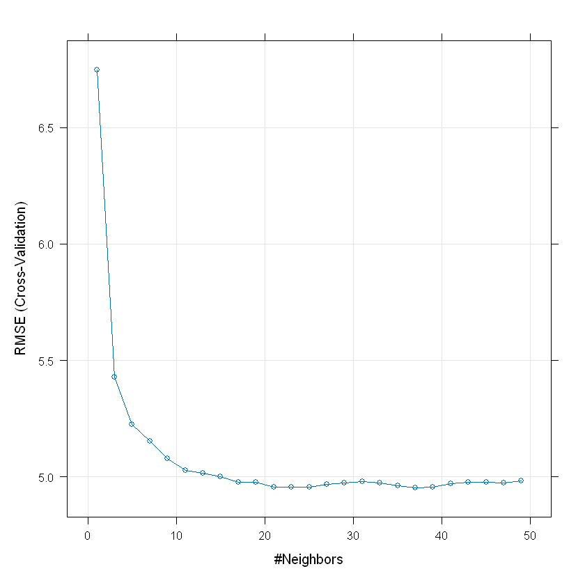

```r
# k optimo con cross-validation 10 folds
trctrl = trainControl(method = "cv", number = 10)
set.seed(2103)
knn.model = train(y ~ ., data = df.train.glm, method = "knn",
                    trControl = trctrl,
                    tuneGrid = expand.grid(k = seq(1, 50, 2)))

plot(knn.model)
knn.model$bestTune
```

Recordemos que el RMSE mide la diferencia entre los valores predichos por el modelo y los valores reales en un conjunto de datos, y en esta gráfica con cross-validation 10 folks vemos cómo se comporta esta diferencia a medida que aumentamos el número de vecinos cercanos. Entre 10 y 20 vecinos vemos que la métrica no tiene cambios significativos, por lo cual el valor de 15 k podría ser un buen parámetro para el desarrollo de un modelo (captura en este punto bien las relaciones).

Utiliza este k óptimo para predecir en el test.

```r
knn.opt = knn.reg(x.train.scaled, x.test.scaled, y = df.y[ind.train], k = 15)
str(knn.opt)
```

```
List of 7
 $ call     : language knn.reg(train = x.train.scaled, test = x.test.scaled, y = df.y[ind.train],      k = 15)
 $ k        : num 15
 $ n        : int 1250
 $ pred     : num [1:1250] 0.973 1.473 3.773 0.713 1.053 ...
 $ residuals: NULL
 $ PRESS    : NULL
 $ R2Pred   : NULL
 - attr(*, "class")= chr "knnReg"
```

Con el modelo k=15 se calculan las métricas para evaluar el rendimiento de este modelo.

```r
#outbin.knn.opt
outbin.knn.opt = as.double(knn.opt$pred >= 1)
```

```r
#validación
#RMSE
rmse.knn.opt = rmse(knn.opt$pred, df.r.test$y)

#ratio de varianza
rv.knn.opt = var(knn.opt$pred) / var(df.r.test$y)

#Correlación Spearman
cor.knn.opt = cor(df.r.test$y, knn.opt$pred, method = "spearman")

#accuracy
acc.knn.opt = acc.class(outbin.knn.opt, outbin.test.knn)

cat("Modelo KNN 15 vecinos", "\n")
cat("RMSE: ", rmse.knn.opt, "\n")
cat("rv: ", rv.knn.opt, "\n")
cat("Correlación Spearman: ", cor.knn.opt, "\n")
cat("Accuracy: ", acc.knn.opt, "\n")
```

```
Modelo KNN 15 vecinos
RMSE:  4.320054
rv:  0.3574756
Correlación Spearman:  0.6223944
RMSE:  4.320054
rv:  0.3574756
Correlación Spearman:  0.6223944
Accuracy:  0.7776
```

Los resultados muestran un RMSE mucho mejor si se compara con un k=1 y acorde a lo analizado en la gráfica anterior (RMSE vr vecinos cercanos); además, se observa coherencia con los resultados obtenidos de modelos anteriores. Se observa un rv bajo, indicando una baja explicación de la variación de la precipitación por parte del modelo; y una correlación de Spearman coherente con los resultados obtenidos en modelos anteriores. En cuanto al accuracy encontramos un menor rendimiento en comparación con modelos anteriores.

Valida las dos predicciones (con k=1 y con k=óptimo) en el test, en función de las medidas que se han ido utilizando en los apartados anteriores.

Pregunta: ¿Qué diferencias obtienes entre las dos versiones utilizadas de la técnica k-NN? ¿A qué se deben?

```r
resultados.knn = matrix(c(rmse.knn.1, rv.knn.1, cor.knn.1, rmse.knn.opt, rv.knn.opt, cor.knn.opt), nrow = 2, byrow = T)
colnames(resultados.knn) = c("RMSE", "rv", "Correlación")
rownames(resultados.knn) = c("KNN 1 vecino", "KNN 15 vecinos")
resultados.knn

#acurracy knn matriz
acc.knn = matrix(c(acc.knn.1, acc.knn.opt), nrow = 1, byrow = T)
colnames(acc.knn) = c("1 vecino", "15 vecinos")
rownames(acc.knn) = c("Accuracy")
acc.knn
```

A matrix: 2 × 3 of type dbl

|  | RMSE | rv | Correlación |
| --- | --- | --- | --- |
| KNN 1 vecino | 6.845634 | 1.7576912 | 0.5507482 |
| KNN 15 vecinos | 4.320054 | 0.3574756 | 0.6223944 |

A matrix: 1 × 2 of type dbl

|  | 1 vecino | 15 vecinos |
| --- | --- | --- |
| Accuracy | 0.84 | 0.7776 |

Como se analizó anteriormente, al implementar k=1, se observa un RMSE elevado y una alta variabilidad en las predicciones (alta rv), lo que sugiere un modelo sobreajustado. En este caso, el modelo es sensible a los valores atípicos o ruido en los datos, ya que solo considera el vecino más cercano, lo que puede hacer que las predicciones sean inestables y menos precisas. En cambio, al aumentar el número de vecinos a k=15, se observa una disminución significativa en el RMSE y una reducción de la variabilidad en las predicciones (rv más bajo). El modelo está utilizando una mayor cantidad de datos para hacer sus predicciones, lo que suaviza las predicciones y las hace menos sensibles al ruido en los datos. Este comportamiento es característico de los modelos kNN, donde k pequeño puede llevar al sobreajuste, mientras que un k más grande tiende a hacer el modelo más generalizado y robusto; en lugar de centrarse en los vecinos más relevantes para la predicción, el modelo considera muchos más puntos de datos, lo que puede hacer que el modelo sea demasiado general y no se ajuste bien a las variaciones en los datos.

En cuanto a la correlación de Spearman, ambos valores presentan correlaciones moderadas, pero con k=15 obtenemos un valor ligeramente mejor. Esto refleja que, al aumentar el número de vecinos, el modelo es más capaz de captar patrones consistentes entre las predicciones y los valores reales, mejorando la relación entre ambos.

Lo mencionado anteriormente, hace importante considerar un equilibrio en el número de vecinos a considerar en el modelo, de tal manera que se pueda garantizar precisión y generalización.

## Conclusiones generales (2 puntos)

A la vista de los resultados obtenidos, argumenta razonadamente qué técnica o técnicas serían las mejores para la predicción de lluvia en Lisboa. Justifica tu respuesta.

```r
#REsultados de métricas modelos de predicción de precipitación
resultados.completos = rbind(result.r.tree, result.rf.r, resultado.glm, resultados.knn)

resultados.completos

#Resultados accuracy - modelos de clasificación ocurrencia
resultados.acc = matrix(c(acc.tree.1, acc.rf.1, acc.glm.1.test, acc.knn.1, acc.knn.opt), nrow = 1, byrow = T)
colnames(resultados.acc) = c("Tree", "Random Forest", "GLM", "KNN 1 vecino", "KNN 15 vecinos")
rownames(resultados.acc) = c("Accuracy")
resultados.acc
```

A matrix: 7 × 3 of type dbl

|  | RMSE | rv | Correlación |
| --- | --- | --- | --- |
| R.Tree completo | 4.486581 | 0.3409243 | 0.6147733 |
| R.Tree lluvia | 4.926077 | 0.7201311 | 0.6115594 |
| R.Forest completo | 4.312477 | 0.4529322 | 0.6086981 |
| R.Forest lluvia | 4.550188 | 0.6802172 | 0.6037957 |
| GLM solo lluvia | 4.317608 | 0.6833197 | 0.6091890 |
| KNN 1 vecino | 6.845634 | 1.7576912 | 0.5507482 |
| KNN 15 vecinos | 4.320054 | 0.3574756 | 0.6223944 |

A matrix: 1 × 5 of type dbl

|  | Tree | Random Forest | GLM | KNN 1 vecino | KNN 15 vecinos |
| --- | --- | --- | --- | --- | --- |
| Accuracy | 0.8656 | 0.872 | 0.8776 | 0.84 | 0.7776 |

Partiendo de los resultados obtenidos, las mejores técnicas para esta partición de datos son GLM y Random Forest entrenado con solo lluvia. Es importante recordar que las métricas de ambos modelos fueron similares, presentando un rv de 0.68, que indica que las predicciones del modelo capturan la variabilidad de los datos reales de manera adecuada; una correlación de Spearman de 0.60, indicando una correlación positiva moderada entre las predicciones del modelo y los valores reales; y un RMSE de 4.3 para GLM y 4.5 para RF lluvia, solo con una diferencia de 0.2 mm, donde en términos generales ambos modelos tienen un error similar en sus predicciones.

Ahora bien, hay que comparar otros aspectos para considerar un modelo sobre el otro, como por ejemplo la interpretabilidad, donde el GLM ofrece un modelo más sencillo e interpretable, permitiendo la identificación de variables significativas para la predicción de precipitación. En el caso de RF este tipo de análisis es más complicado, por lo cual se suele partir de un árbol individual para la exploración de variables, pero no podríamos asegurar que las mismas variables son significativas en todas las particiones de los árboles, especialmente porque se trabaja con cantidad de variables reducida para cada partición de los árboles generados.

Hay que destacar de RF que genera un modelo más robusto debido a que promedia el resultado de muchos arboles de tal forma que logra capturar relaciones complejas entre las variables y evitando el sobreajuste. Además, realiza promedios de las predicciones de estos árboles, lo que disminuye la varianza y mejora la capacidad de generalización. Sin embargo, esta misma característica hace que requiera mayor coste computacional para desarrollar debido a que dependen de la generación de múltiples árboles para garantizar una estabilidad en el modelo.

Es importante considerar el tipo de variable objetivo, su naturaleza y el comportamiento de los datos, debido a que esto podría representar la diferencia entre un modelo y otro. GLM suele ser menos flexible que FR, en cuanto a la captura de relaciones complejas, especialmente en datos con patrones no lineales, por lo cual sería bueno explorar más en detalle este aspecto con otras particiones de datos para revisar si el comportamiento observado en los modelos prevalece.

Para estos datos, se puede decir que un modelo GLM es suficiente para predecir los eventos de lluvia y precipitación, debido a que se observa un modelo capaz de generalizar y predecir con un error moderado. Pese a las cualidades de Random Forest para generar modelos más robustos, en este caso no representa una diferencia significativa. Sus resultados son iguales comparados con un modelo más simple como un GLM, por lo cual no justifica el generar un modelo más complejo y que requiere un mayor coste computacional. Además, resaltar las ventajas de GLM para generar un modelo interpretable.

Los otros modelos, Single Tree y KNN, no arrojaron métricas mejores que las mencionadas anteriormente. En el caso de los Single Tree, estos son muy sensibles a la partición inicial de los datos, lo que puede llevar a la generación de diferentes árboles y afectar la estabilidad de las métricas, especialmente en datos con alta variabilidad. Por otro lado, el modelo KNN, aun con el valor óptimo de k, presentó un bajo ratio de varianza, lo cual indica que no captura adecuadamente la variabilidad de los datos. Aunque KNN mostró una buena correlación y un error similar a los modelos anteriores, esto no es suficiente para considerarlo más robusto que GLM o Random Forest.

Es importante decir que estos resultados están condicionados a la partición inicial de los datos, donde se usó una técnica Hold out y no se implemento todo el dataset de meteo. Además, a la técnica de reducción de la dimensionalidad basada en la correlación de spearman, que quizás no es la más indicada para este tipo de datos, debido a que no necesariamente captura la complejidad de las relaciones lineales y no lineales que pueden existir entre las variables meteorológicas. Otras alternativas a considerar sería PCA que busca capturar la mayor cantidad posible de varianza en los datos, combinando las variables originales en componentes principales, siendo útil cuando hay muchas variables correlacionadas entre sí, reduciendo la redundancia y conservando la información relevante (datos con múltiples factores).